# DATA621 Homework #1 - Appendix A

William Aiken, Donald Butler, Michael Ippolito, Bharani Nittala, Leticia Salazar, Santiago Torres

9/25/2022

## 1. DATA EXPLORATION

Due to the number of fields in this data, I broke the dataset into intuitive sections and explored each section individually.

```r
# Load data
eval_df <- read.csv("https://raw.githubusercontent.com/catfoodlover/DATA621/main/HW1/moneyball-evaluation-data.csv")
train_df <- read.csv("https://raw.githubusercontent.com/catfoodlover/DATA621/main/HW1/moneyball-training-data.csv")
```

### Base Hits by Batter

- TARGET_WINS - Number of wins
- TEAM_BATTING_H - Base Hits by batters (1B,2B,3B,HR)
- TEAM_BATTING_2B - Doubles by batters (2B)
- TEAM_BATTING_3B - Triples by batters (3B)
- TEAM_BATTING_HR - Homeruns by batters (4B)

The means and medians are very similar for the base hits variables implying little skew to the distributions.

```r
# Summary
train_df %>% select(c("TARGET_WINS", "TEAM_BATTING_H","TEAM_BATTING_2B","TEAM_BATTING_3B","TEAM_BATTING_HR")) %>% gtsummary::tbl_summary(statistic =list(c("TARGET_WINS", "TEAM_BATTING_H","TEAM_BATTING_2B","TEAM_BATTING_3B","TEAM_BATTING_HR") ~ "{mean} {median} {sd}"
))
```

| **Characteristic** | **N = 2,276**<sup>1</sup> |
| --- | --- |
| TARGET_WINS | 81 82 16 |
| TEAM_BATTING_H | 1,469 1,454 145 |
| TEAM_BATTING_2B | 241 238 47 |
| TEAM_BATTING_3B | 55 47 28 |
| TEAM_BATTING_HR | 100 102 61 |

<sup>1</sup> Mean Median SD

We see tight distributions except for all base hits by batters (TEAM_BATTING_H).

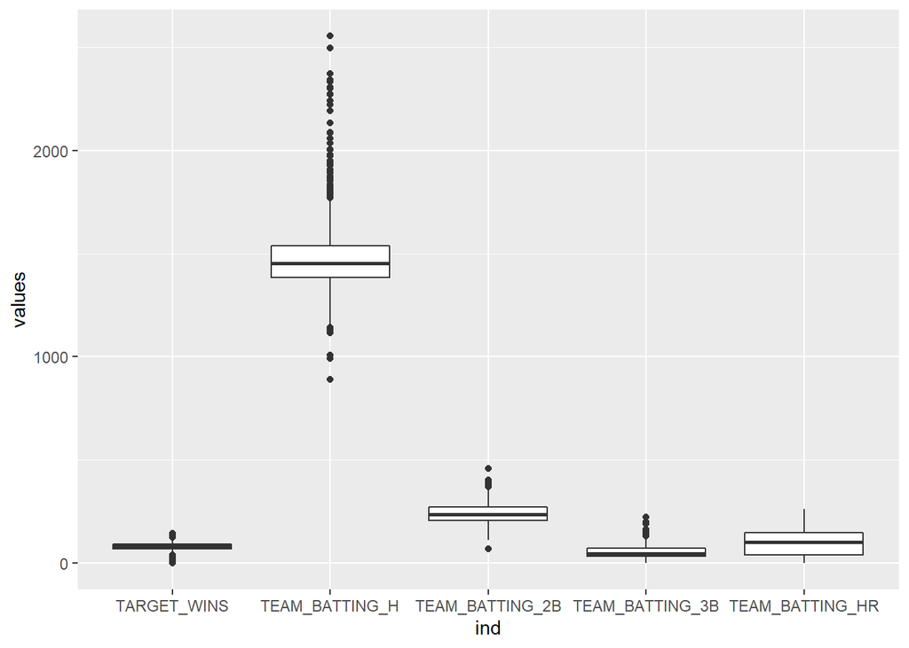

```r
# Box plots
temp <- train_df %>% select(c("TARGET_WINS", "TEAM_BATTING_H","TEAM_BATTING_2B","TEAM_BATTING_3B","TEAM_BATTING_HR"))
ggplot2::ggplot(stack(temp), aes(x = ind, y = values)) +
  geom_boxplot()
```

Interestingly, doubles and triples are correlated with base hits while home runs are not.

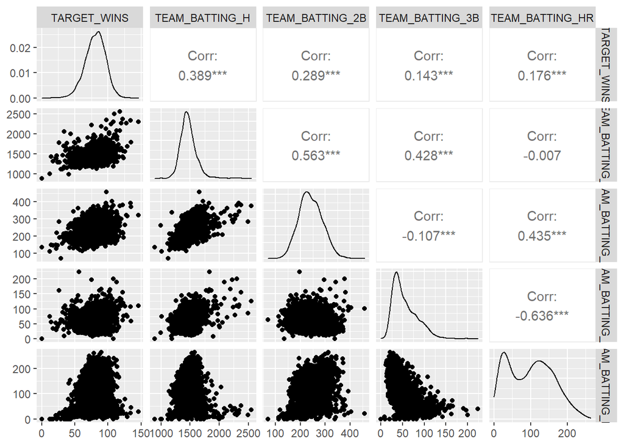

```r
# Correlation plot
train_df %>% select(c("TARGET_WINS", "TEAM_BATTING_H","TEAM_BATTING_2B","TEAM_BATTING_3B","TEAM_BATTING_HR")) %>% GGally::ggpairs()
```

### Batting

- TARGET_WINS - Number of wins
- TEAM_BATTING_BB - Walks by batters
- TEAM_BATTING_HBP - Batters hit by pitch (get a free base)
- TEAM_BATTING_SO - Strikeouts by batters
- TEAM_BASERUN_SB - Stolen bases
- TEAM_BASERUN_CS - Caught stealing

The measures of central tendency show us that most of these variable have slight skew to their distributions. Stolen bases has a large right skew to its distribution.

We are missing values for stikeouts, stolen bases and caught stealing.

```r
# Summary
train_df %>% select(c("TEAM_BATTING_BB", "TEAM_BATTING_SO", "TEAM_BASERUN_SB", "TEAM_BASERUN_CS")) %>% gtsummary::tbl_summary(statistic =list(c("TEAM_BATTING_BB", "TEAM_BATTING_SO", "TEAM_BASERUN_SB", "TEAM_BASERUN_CS") ~ "{mean} {median} {sd}"
))
```

| **Characteristic** | **N = 2,276**<sup>1</sup> |
| --- | --- |
| TEAM_BATTING_BB | 502 512 123 |
| TEAM_BATTING_SO | 736 750 249 |
| Unknown | 102 |
| TEAM_BASERUN_SB | 125 101 88 |
| Unknown | 131 |
| TEAM_BASERUN_CS | 53 49 23 |
| Unknown | 772 |

<sup>1</sup> Mean Median SD

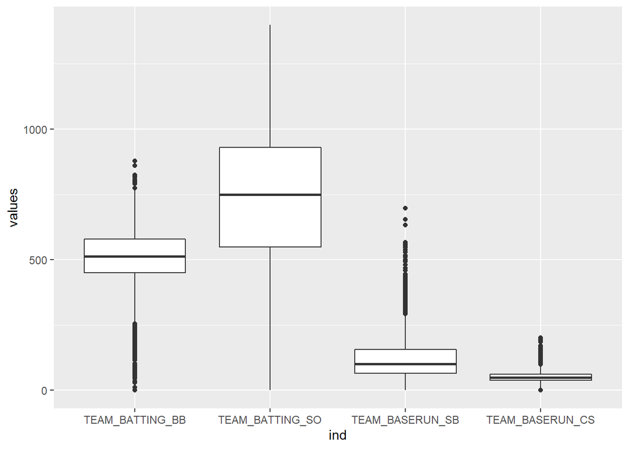

```r
# Box plots
temp <- train_df %>% select(c("TEAM_BATTING_BB", "TEAM_BATTING_SO", "TEAM_BASERUN_SB", "TEAM_BASERUN_CS"))
ggplot2::ggplot(stack(temp), aes(x = ind, y = values)) +
  geom_boxplot()
```

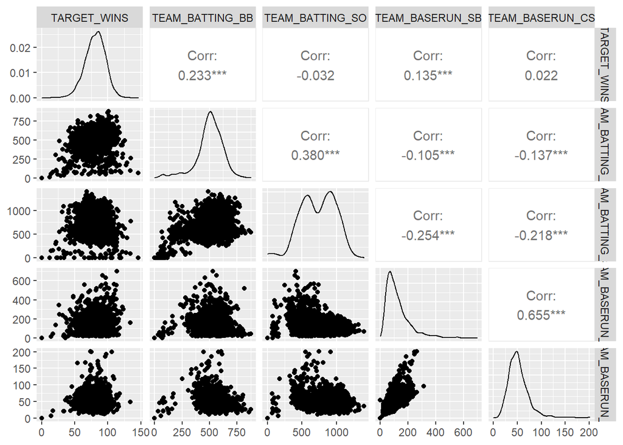

```r
# Correlation plot
train_df %>% select(c("TARGET_WINS", "TEAM_BATTING_BB", "TEAM_BATTING_SO", "TEAM_BASERUN_SB", "TEAM_BASERUN_CS")) %>% GGally::ggpairs()
```

### Fielding

- TARGET_WINS - Number of wins
- TEAM_FIELDING_E - Errors
- TEAM_FIELDING_DP - Double Plays

The Errors variable(TEAM_FIELDING_E) has an incredibly right skewed distribution. We are missing some Double Plays values.

```r
# Summary
train_df %>% select(c("TEAM_FIELDING_E", "TEAM_FIELDING_DP")) %>% gtsummary::tbl_summary(statistic =list(c("TEAM_FIELDING_E", "TEAM_FIELDING_DP") ~ "{mean} {median} {sd}"
))
```

| **Characteristic** | **N = 2,276**<sup>1</sup> |
| --- | --- |
| TEAM_FIELDING_E | 246 159 228 |
| TEAM_FIELDING_DP | 146 149 26 |
| Unknown | 286 |

<sup>1</sup> Mean Median SD

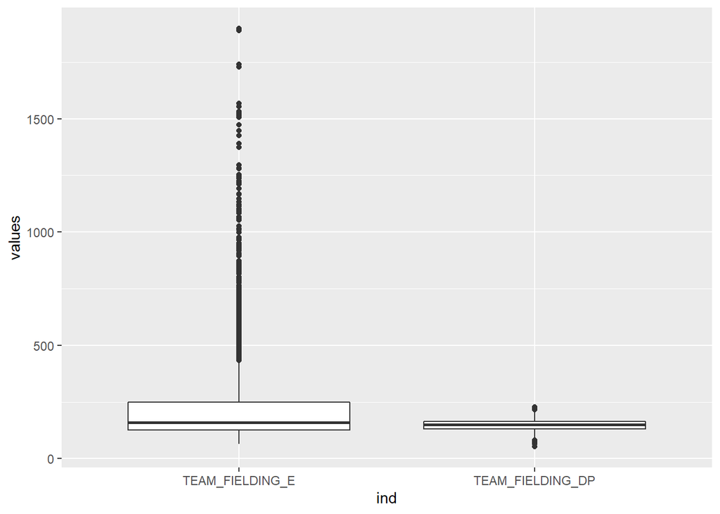

```r
# Box plots
temp <- train_df %>% select(c("TEAM_FIELDING_E", "TEAM_FIELDING_DP"))
ggplot2::ggplot(stack(temp), aes(x = ind, y = values)) +
  geom_boxplot()
```

Both the Fielding variables are negatively correlated with Wins.

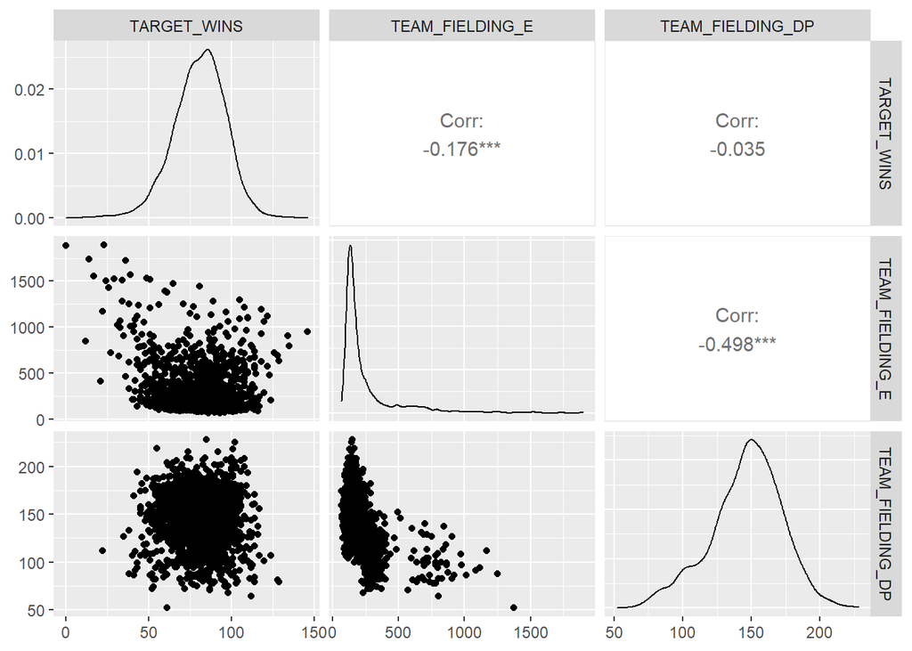

```r
# Correlation plot
train_df %>% select(c("TARGET_WINS", "TEAM_FIELDING_E", "TEAM_FIELDING_DP"))%>% GGally::ggpairs()
```

### Pitching

- TARGET_WINS - Number of wins
- TEAM_PITCHING_BB - Walks allowed
- TEAM_PITCHING_H - Hits allowed
- TEAM_PITCHING_HR - Homeruns allowed
- TEAM_PITCHING_SO - Strikeouts by pitchers

Hits allowed (TEAM_PITCHING_H) has a right skew and we are missing some Strikeouts by pitcher (TEAM_PITCHING_SO) values.

```r
# Summary
train_df %>% select(c("TEAM_PITCHING_H", "TEAM_PITCHING_HR", "TEAM_PITCHING_BB", "TEAM_PITCHING_SO")) %>% gtsummary::tbl_summary(statistic =list(c("TEAM_PITCHING_H", "TEAM_PITCHING_HR", "TEAM_PITCHING_BB", "TEAM_PITCHING_SO") ~ "{mean} {median} {sd}"
))
```

| **Characteristic** | **N = 2,276**<sup>1</sup> |
| --- | --- |
| TEAM_PITCHING_H | 1,779 1,518 1,407 |
| TEAM_PITCHING_HR | 106 107 61 |
| TEAM_PITCHING_BB | 553 536 166 |
| TEAM_PITCHING_SO | 818 814 553 |
| Unknown | 102 |

<sup>1</sup> Mean Median SD

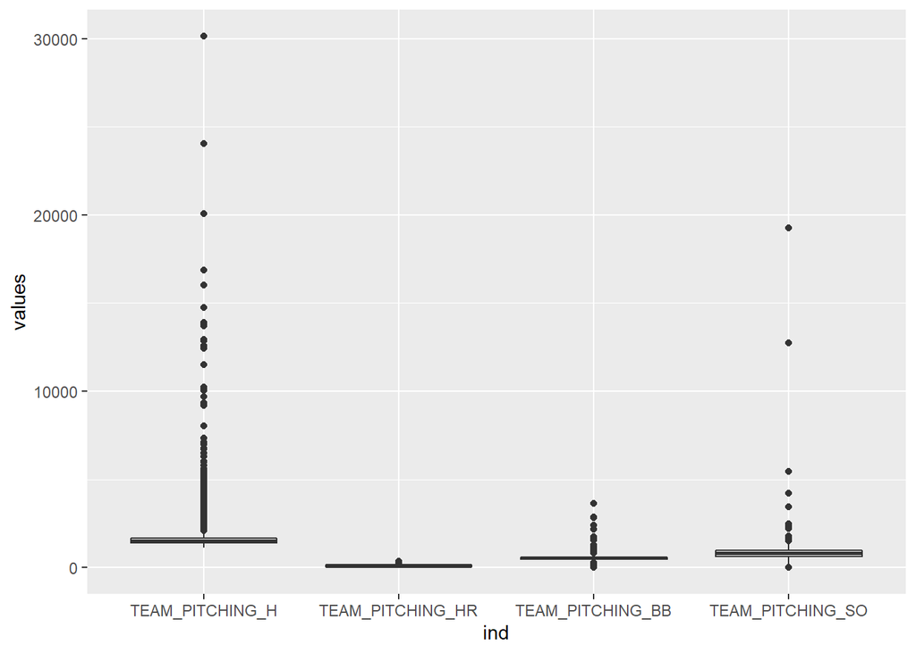

```r
# Box plots
temp <- train_df %>% select(c("TEAM_PITCHING_H", "TEAM_PITCHING_HR", "TEAM_PITCHING_BB", "TEAM_PITCHING_SO"))
ggplot2::ggplot(stack(temp), aes(x = ind, y = values)) +
  geom_boxplot()
```

Hits allowed is negatively correlated with Winning.

Interestingly, Home runs allowed is positively correlated with Winning.

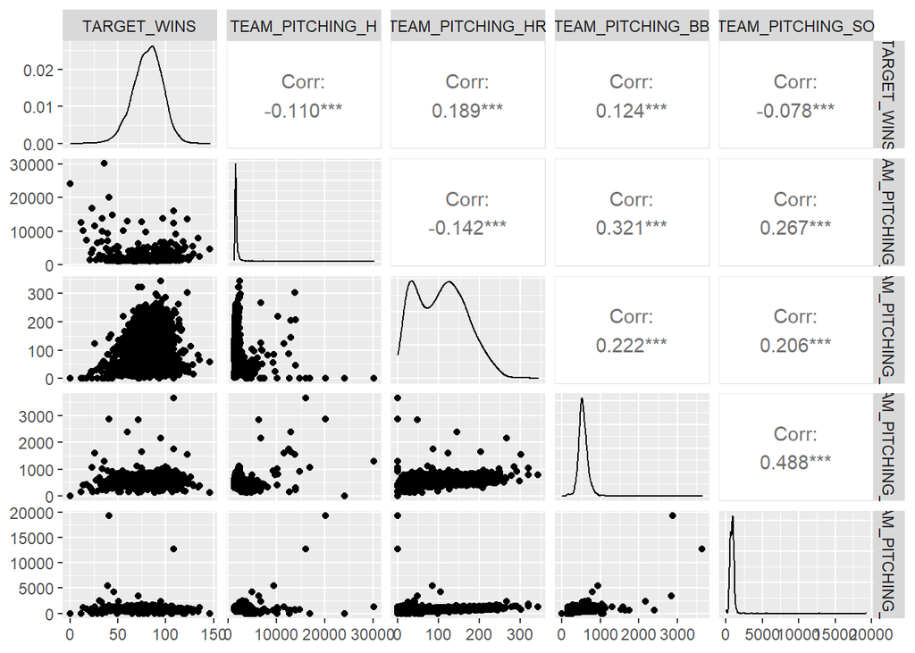

```r
# Correlation plot
train_df %>% select(c("TARGET_WINS","TEAM_PITCHING_H", "TEAM_PITCHING_HR", "TEAM_PITCHING_BB", "TEAM_PITCHING_SO"))%>% GGally::ggpairs()
```

$~$

### **Data Overview**

The data set contains approximately 2276 records. Each record represents a professional baseball team from the years 1871 to 2006 inclusive. Each record has the performance of the team for the given year, with all of the statistics adjusted to match the performance of a 162 game season.

Below is a short description of the variables:

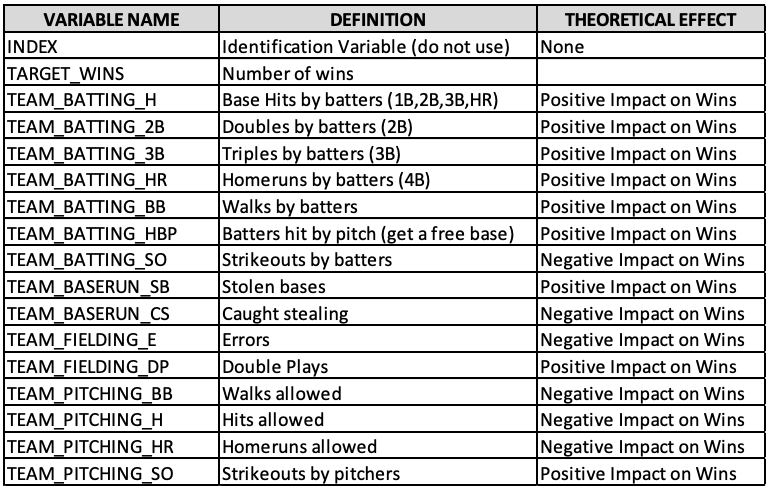

https://raw.githubusercontent.com/letisalba/Data_621/master/Homework_1/Images/homework1_table.png

- INDEX - Identification Variable
- TARGET_WINS - Number of wins
- TEAM_BATTING_H - Base Hits by batters (1B,2B,3B,HR)
- TEAM_BATTING_2B - Doubles by batters (2B)
- TEAM_BATTING_3B - Triples by batters (3B)
- TEAM_BATTING_HR - Homeruns by batters (4B)
- TEAM_BATTING_BB - Walks by batters
- TEAM_BATTING_HBP - Batters hit by pitch (get a free base)
- TEAM_BATTING_SO - Strikeouts by batters
- TEAM_BASERUN_SB - Stolen bases
- TEAM_BASERUN_CS - Caught stealing
- TEAM_FIELDING_E - Errors
- TEAM_FIELDING_DP - Double Plays
- TEAM_PITCHING_BB - Walks allowed
- TEAM_PITCHING_H - Hits allowed
- TEAM_PITCHING_HR - Homeruns allowed
- TEAM_PITCHING_SO - Strikeouts by pitchers

$~$

#### **Objective**

To build a multiple linear regression model on the training data to predict *TARGET_WINS*, which is the number of wins for the team.

$~$

### **Data Exploration and Preparation**

```r
# Read data
baseball_df <- read.csv('https://raw.githubusercontent.com/letisalba/Data_621/master/Homework_1/csv/moneyball-training-data.csv')
baseball_eval <- read.csv('https://raw.githubusercontent.com/letisalba/Data_621/master/Homework_1/csv/moneyball-evaluation-data.csv')

# Data overview
head(baseball_df)
```

```
##   INDEX TARGET_WINS TEAM_BATTING_H TEAM_BATTING_2B TEAM_BATTING_3B
## 1     1          39           1445             194              39
## 2     2          70           1339             219              22
## 3     3          86           1377             232              35
## 4     4          70           1387             209              38
## 5     5          82           1297             186              27
## 6     6          75           1279             200              36
##   TEAM_BATTING_HR TEAM_BATTING_BB TEAM_BATTING_SO TEAM_BASERUN_SB
## 1              13             143             842              NA
## 2             190             685            1075              37
## 3             137             602             917              46
## 4              96             451             922              43
## 5             102             472             920              49
## 6              92             443             973             107
##   TEAM_BASERUN_CS TEAM_BATTING_HBP TEAM_PITCHING_H TEAM_PITCHING_HR
## 1              NA               NA            9364               84
## 2              28               NA            1347              191
## 3              27               NA            1377              137
## 4              30               NA            1396               97
## 5              39               NA            1297              102
## 6              59               NA            1279               92
##   TEAM_PITCHING_BB TEAM_PITCHING_SO TEAM_FIELDING_E TEAM_FIELDING_DP
## 1              927             5456            1011               NA
## 2              689             1082             193              155
## 3              602              917             175              153
## 4              454              928             164              156
## 5              472              920             138              168
## 6              443              973             123              149
```

```r
dim(baseball_df)
```

```
## [1] 2276   17
```

```r
# Data summary
summary(baseball_df)
```

```
##      INDEX         TARGET_WINS     TEAM_BATTING_H TEAM_BATTING_2B
##  Min.   :   1.0   Min.   :  0.00   Min.   : 891   Min.   : 69.0
##  1st Qu.: 630.8   1st Qu.: 71.00   1st Qu.:1383   1st Qu.:208.0
##  Median :1270.5   Median : 82.00   Median :1454   Median :238.0
##  Mean   :1268.5   Mean   : 80.79   Mean   :1469   Mean   :241.2
##  3rd Qu.:1915.5   3rd Qu.: 92.00   3rd Qu.:1537   3rd Qu.:273.0
##  Max.   :2535.0   Max.   :146.00   Max.   :2554   Max.   :458.0
##
##  TEAM_BATTING_3B  TEAM_BATTING_HR  TEAM_BATTING_BB TEAM_BATTING_SO
##  Min.   :  0.00   Min.   :  0.00   Min.   :  0.0   Min.   :   0.0
##  1st Qu.: 34.00   1st Qu.: 42.00   1st Qu.:451.0   1st Qu.: 548.0
##  Median : 47.00   Median :102.00   Median :512.0   Median : 750.0
##  Mean   : 55.25   Mean   : 99.61   Mean   :501.6   Mean   : 735.6
##  3rd Qu.: 72.00   3rd Qu.:147.00   3rd Qu.:580.0   3rd Qu.: 930.0
##  Max.   :223.00   Max.   :264.00   Max.   :878.0   Max.   :1399.0
##                                                    NA's   :102
##  TEAM_BASERUN_SB TEAM_BASERUN_CS TEAM_BATTING_HBP TEAM_PITCHING_H
##  Min.   :  0.0   Min.   :  0.0   Min.   :29.00    Min.   : 1137
##  1st Qu.: 66.0   1st Qu.: 38.0   1st Qu.:50.50    1st Qu.: 1419
##  Median :101.0   Median : 49.0   Median :58.00    Median : 1518
##  Mean   :124.8   Mean   : 52.8   Mean   :59.36    Mean   : 1779
##  3rd Qu.:156.0   3rd Qu.: 62.0   3rd Qu.:67.00    3rd Qu.: 1682
##  Max.   :697.0   Max.   :201.0   Max.   :95.00    Max.   :30132
##  NA's   :131     NA's   :772     NA's   :2085
##  TEAM_PITCHING_HR TEAM_PITCHING_BB TEAM_PITCHING_SO  TEAM_FIELDING_E
##  Min.   :  0.0    Min.   :   0.0   Min.   :    0.0   Min.   :  65.0
##  1st Qu.: 50.0    1st Qu.: 476.0   1st Qu.:  615.0   1st Qu.: 127.0
##  Median :107.0    Median : 536.5   Median :  813.5   Median : 159.0
##  Mean   :105.7    Mean   : 553.0   Mean   :  817.7   Mean   : 246.5
##  3rd Qu.:150.0    3rd Qu.: 611.0   3rd Qu.:  968.0   3rd Qu.: 249.2
##  Max.   :343.0    Max.   :3645.0   Max.   :19278.0   Max.   :1898.0
##                                    NA's   :102
##  TEAM_FIELDING_DP
##  Min.   : 52.0
##  1st Qu.:131.0
##  Median :149.0
##  Mean   :146.4
##  3rd Qu.:164.0
##  Max.   :228.0
##  NA's   :286
```

```r
print(paste0('Number of observations: ', nrow(baseball_df)))
```

```
## [1] "Number of observations: 2276"
```

```r
print(paste0('Observations per year, 1871 - 2006: ',round(nrow(baseball_df)/(2006-1871),2)))
```

```
## [1] "Observations per year, 1871 - 2006: 16.86"
```

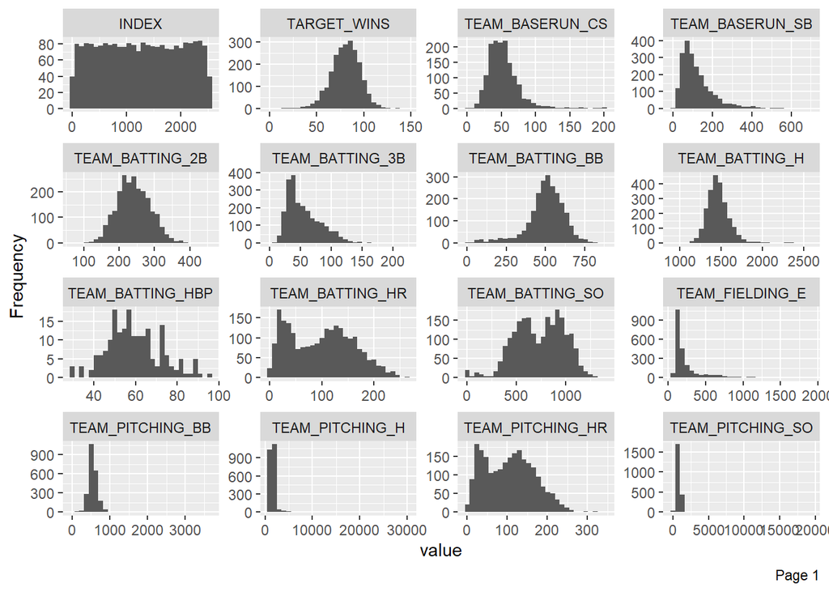

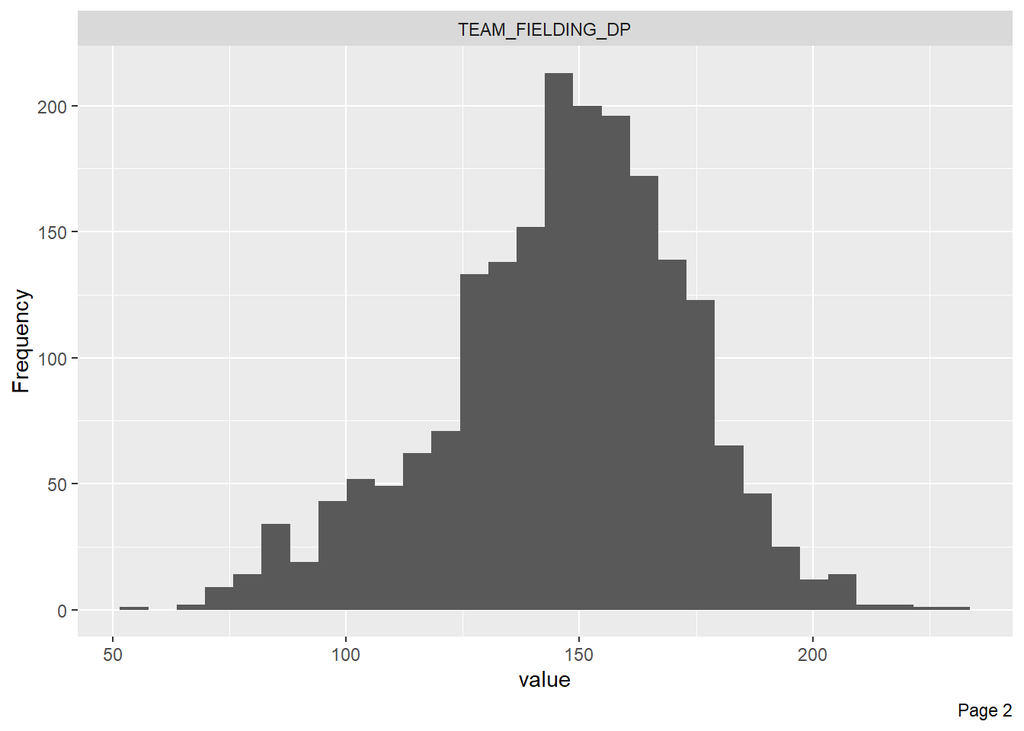

```r
# Distribution
plot_histogram(baseball_df)
```

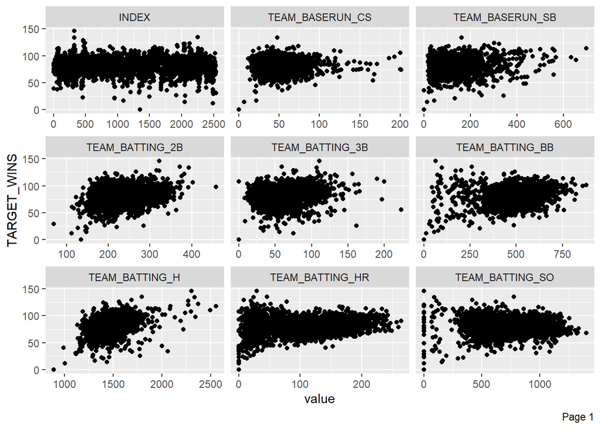

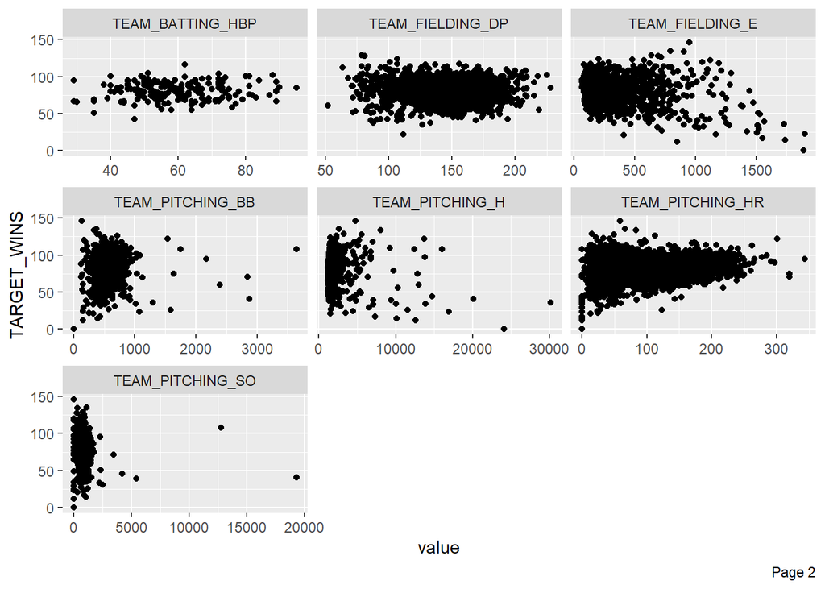

```r
# Plot against the response variable
plot_scatterplot(baseball_df, by = "TARGET_WINS")
```

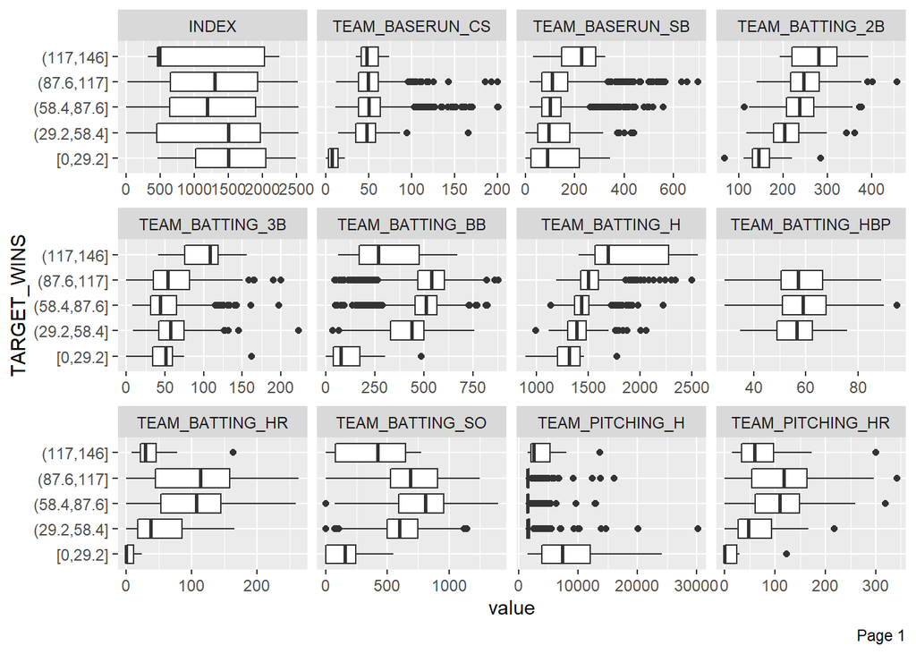

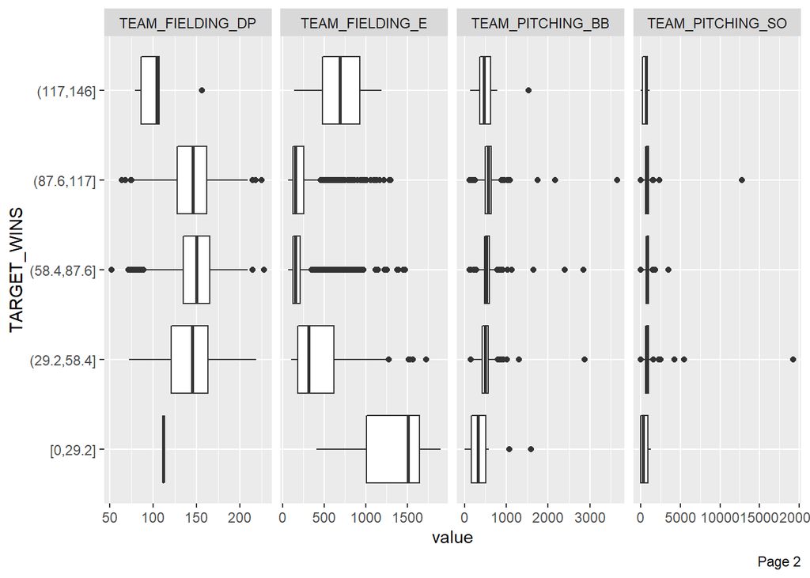

```r
# Boxplot for train dataset
plot_boxplot(baseball_df, by = "TARGET_WINS")
```

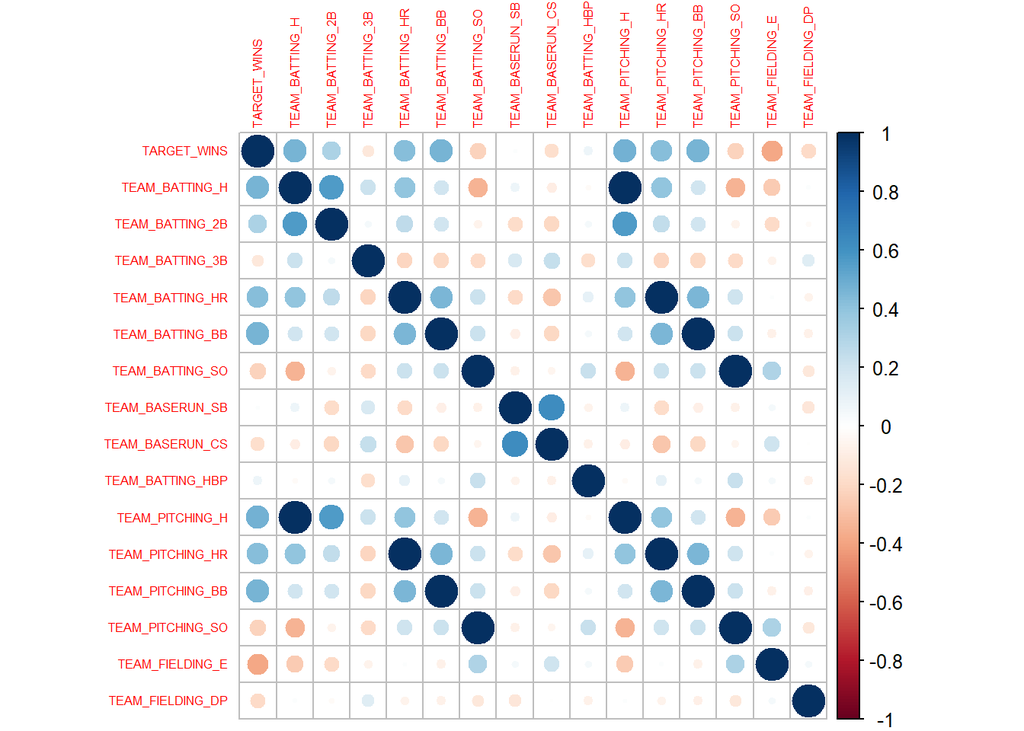

```r
# Correlation plot
corrplot(cor(baseball_df[,2:17], use = 'complete.obs'), tl.cex = 0.5)
```

Looking at the correlation plot, there appear to be several strong correlations between explanatory variables and the target. From an initial inspection, it appears the team should focus on getting players on base through hits or walks. Teams can still win if the pitchers allow homeruns, hits and walks to the other team.

$~$

*Variables with Highest Positive Correlation with TARGET_WINS:*

- TEAM_BATTING_H = 0.47
- TEAM_BATTING_HR = 0.42
- TEAM_BATTING_BB = 0.47
- TEAM_PITCHING_H = 0.47
- TEAM_PITCHING_HR = 0.42
- TEAM_PITCHING_BB = 0.47

To win more games it makes sense the team will need to make fewer errors.

$~$

$~$

*Positive Correlations between variables*:

- TEAM_PITCHING_H and TEAM_BATTING_H = 0.99
- TEAM_PITCHING_HR and TEAM_BATTING_HR = 0.99
- TEAM_PITCHING_BB and TEAM_BATTING_BB = 0.99
- TEAM_PITCHING_SO and TEAM_BATTING_SO = 0.99

$~$

#### **Missing values**

```r
# Missing values
round(100*colSums(is.na(baseball_df))/nrow(baseball_df),2) %>%
  kable() %>%
  kable_styling(bootstrap_options = c("striped", "hover", "condensed"), font_size = 13)
```

|  | x |
| --- | --- |
| INDEX | 0.00 |
| TARGET_WINS | 0.00 |
| TEAM_BATTING_H | 0.00 |
| TEAM_BATTING_2B | 0.00 |
| TEAM_BATTING_3B | 0.00 |
| TEAM_BATTING_HR | 0.00 |
| TEAM_BATTING_BB | 0.00 |
| TEAM_BATTING_SO | 4.48 |
| TEAM_BASERUN_SB | 5.76 |
| TEAM_BASERUN_CS | 33.92 |
| TEAM_BATTING_HBP | 91.61 |
| TEAM_PITCHING_H | 0.00 |
| TEAM_PITCHING_HR | 0.00 |
| TEAM_PITCHING_BB | 0.00 |
| TEAM_PITCHING_SO | 4.48 |
| TEAM_FIELDING_E | 0.00 |
| TEAM_FIELDING_DP | 12.57 |

In terms of missing values, there are two variables missing many observations. TEAM_BATTING_HBP is missing over 90% of its values, while TEAM_BASERUN_CS is missing just around 30%.

```r
#New DF with Missing Removed
baseball_df_mv <- baseball_df[, !names(baseball_df) %in% c('TEAM_BATTING_HBP','TEAM_BASERUN_CS','TEAM_FIELDING_DP')]
summary(baseball_df_mv)
```

```
##      INDEX         TARGET_WINS     TEAM_BATTING_H TEAM_BATTING_2B
##  Min.   :   1.0   Min.   :  0.00   Min.   : 891   Min.   : 69.0
##  1st Qu.: 630.8   1st Qu.: 71.00   1st Qu.:1383   1st Qu.:208.0
##  Median :1270.5   Median : 82.00   Median :1454   Median :238.0
##  Mean   :1268.5   Mean   : 80.79   Mean   :1469   Mean   :241.2
##  3rd Qu.:1915.5   3rd Qu.: 92.00   3rd Qu.:1537   3rd Qu.:273.0
##  Max.   :2535.0   Max.   :146.00   Max.   :2554   Max.   :458.0
##
##  TEAM_BATTING_3B  TEAM_BATTING_HR  TEAM_BATTING_BB TEAM_BATTING_SO
##  Min.   :  0.00   Min.   :  0.00   Min.   :  0.0   Min.   :   0.0
##  1st Qu.: 34.00   1st Qu.: 42.00   1st Qu.:451.0   1st Qu.: 548.0
##  Median : 47.00   Median :102.00   Median :512.0   Median : 750.0
##  Mean   : 55.25   Mean   : 99.61   Mean   :501.6   Mean   : 735.6
##  3rd Qu.: 72.00   3rd Qu.:147.00   3rd Qu.:580.0   3rd Qu.: 930.0
##  Max.   :223.00   Max.   :264.00   Max.   :878.0   Max.   :1399.0
##                                                    NA's   :102
##  TEAM_BASERUN_SB TEAM_PITCHING_H TEAM_PITCHING_HR TEAM_PITCHING_BB
##  Min.   :  0.0   Min.   : 1137   Min.   :  0.0    Min.   :   0.0
##  1st Qu.: 66.0   1st Qu.: 1419   1st Qu.: 50.0    1st Qu.: 476.0
##  Median :101.0   Median : 1518   Median :107.0    Median : 536.5
##  Mean   :124.8   Mean   : 1779   Mean   :105.7    Mean   : 553.0
##  3rd Qu.:156.0   3rd Qu.: 1682   3rd Qu.:150.0    3rd Qu.: 611.0
##  Max.   :697.0   Max.   :30132   Max.   :343.0    Max.   :3645.0
##  NA's   :131
##  TEAM_PITCHING_SO  TEAM_FIELDING_E
##  Min.   :    0.0   Min.   :  65.0
##  1st Qu.:  615.0   1st Qu.: 127.0
##  Median :  813.5   Median : 159.0
##  Mean   :  817.7   Mean   : 246.5
##  3rd Qu.:  968.0   3rd Qu.: 249.2
##  Max.   :19278.0   Max.   :1898.0
##  NA's   :102
```

```r
#Impute NAs with Median
baseball_df_imputed <- mice(baseball_df_mv, m=5, maxit = 5, method = 'pmm')
baseball_df_final <- complete(baseball_df_imputed)
summary(baseball_df_final)
```

```
##      INDEX         TARGET_WINS     TEAM_BATTING_H TEAM_BATTING_2B
##  Min.   :   1.0   Min.   :  0.00   Min.   : 891   Min.   : 69.0
##  1st Qu.: 630.8   1st Qu.: 71.00   1st Qu.:1383   1st Qu.:208.0
##  Median :1270.5   Median : 82.00   Median :1454   Median :238.0
##  Mean   :1268.5   Mean   : 80.79   Mean   :1469   Mean   :241.2
##  3rd Qu.:1915.5   3rd Qu.: 92.00   3rd Qu.:1537   3rd Qu.:273.0
##  Max.   :2535.0   Max.   :146.00   Max.   :2554   Max.   :458.0
##  TEAM_BATTING_3B  TEAM_BATTING_HR  TEAM_BATTING_BB TEAM_BATTING_SO
##  Min.   :  0.00   Min.   :  0.00   Min.   :  0.0   Min.   :   0.0
##  1st Qu.: 34.00   1st Qu.: 42.00   1st Qu.:451.0   1st Qu.: 542.0
##  Median : 47.00   Median :102.00   Median :512.0   Median : 733.0
##  Mean   : 55.25   Mean   : 99.61   Mean   :501.6   Mean   : 727.5
##  3rd Qu.: 72.00   3rd Qu.:147.00   3rd Qu.:580.0   3rd Qu.: 925.0
##  Max.   :223.00   Max.   :264.00   Max.   :878.0   Max.   :1399.0
##  TEAM_BASERUN_SB TEAM_PITCHING_H TEAM_PITCHING_HR TEAM_PITCHING_BB
##  Min.   :  0.0   Min.   : 1137   Min.   :  0.0    Min.   :   0.0
##  1st Qu.: 67.0   1st Qu.: 1419   1st Qu.: 50.0    1st Qu.: 476.0
##  Median :105.0   Median : 1518   Median :107.0    Median : 536.5
##  Mean   :136.4   Mean   : 1779   Mean   :105.7    Mean   : 553.0
##  3rd Qu.:170.0   3rd Qu.: 1682   3rd Qu.:150.0    3rd Qu.: 611.0
##  Max.   :697.0   Max.   :30132   Max.   :343.0    Max.   :3645.0
##  TEAM_PITCHING_SO  TEAM_FIELDING_E
##  Min.   :    0.0   Min.   :  65.0
##  1st Qu.:  609.0   1st Qu.: 127.0
##  Median :  802.0   Median : 159.0
##  Mean   :  809.9   Mean   : 246.5
##  3rd Qu.:  958.0   3rd Qu.: 249.2
##  Max.   :19278.0   Max.   :1898.0
```

```
## Using  as id variables
```

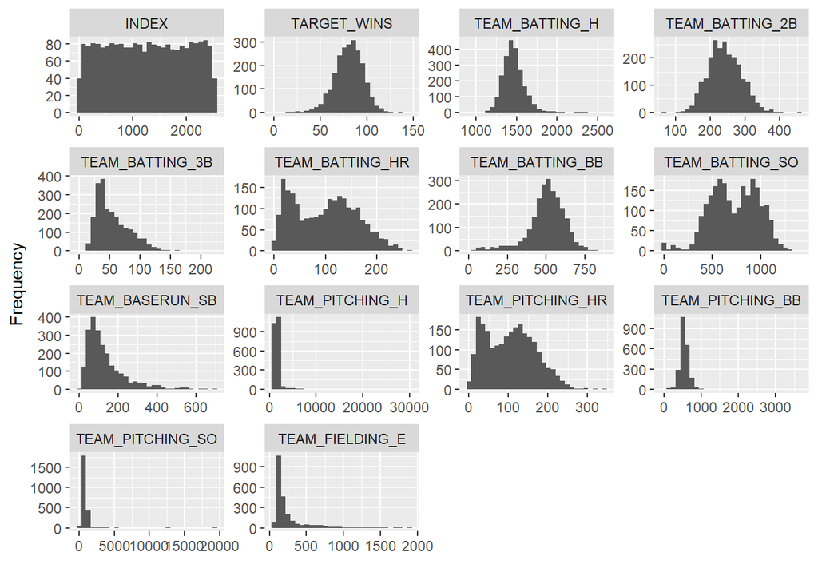

```r
ggplot(melt(baseball_df_final), aes(x=value)) + geom_histogram() + facet_wrap(~variable, scale='free') + labs(x='', y='Frequency')
```

```r
#Replace Error Maxs
baseball_df_final$TEAM_PITCHING_H[baseball_df_final$TEAM_PITCHING_H > 3*sd(baseball_df_final$TEAM_PITCHING_H)] <- median(baseball_df_final$TEAM_PITCHING_H)
baseball_df_final$TEAM_PITCHING_BB[baseball_df_final$TEAM_PITCHING_BB > 3*sd(baseball_df_final$TEAM_PITCHING_BB)] <- median(baseball_df_final$TEAM_PITCHING_BB)
baseball_df_final$TEAM_PITCHING_SO[baseball_df_final$TEAM_PITCHING_SO > 3*sd(baseball_df_final$TEAM_PITCHING_SO)] <- median(baseball_df_final$TEAM_PITCHING_SO)
baseball_df_final$TEAM_FIELDING_E[baseball_df_final$TEAM_FIELDING_E > 3*sd(baseball_df_final$TEAM_FIELDING_E)] <- median(baseball_df_final$TEAM_FIELDING_E)
summary(baseball_df_final)
```

```
##      INDEX         TARGET_WINS     TEAM_BATTING_H TEAM_BATTING_2B
##  Min.   :   1.0   Min.   :  0.00   Min.   : 891   Min.   : 69.0
##  1st Qu.: 630.8   1st Qu.: 71.00   1st Qu.:1383   1st Qu.:208.0
##  Median :1270.5   Median : 82.00   Median :1454   Median :238.0
##  Mean   :1268.5   Mean   : 80.79   Mean   :1469   Mean   :241.2
##  3rd Qu.:1915.5   3rd Qu.: 92.00   3rd Qu.:1537   3rd Qu.:273.0
##  Max.   :2535.0   Max.   :146.00   Max.   :2554   Max.   :458.0
##  TEAM_BATTING_3B  TEAM_BATTING_HR  TEAM_BATTING_BB TEAM_BATTING_SO
##  Min.   :  0.00   Min.   :  0.00   Min.   :  0.0   Min.   :   0.0
##  1st Qu.: 34.00   1st Qu.: 42.00   1st Qu.:451.0   1st Qu.: 542.0
##  Median : 47.00   Median :102.00   Median :512.0   Median : 733.0
##  Mean   : 55.25   Mean   : 99.61   Mean   :501.6   Mean   : 727.5
##  3rd Qu.: 72.00   3rd Qu.:147.00   3rd Qu.:580.0   3rd Qu.: 925.0
##  Max.   :223.00   Max.   :264.00   Max.   :878.0   Max.   :1399.0
##  TEAM_BASERUN_SB TEAM_PITCHING_H TEAM_PITCHING_HR TEAM_PITCHING_BB
##  Min.   :  0.0   Min.   :1137    Min.   :  0.0    Min.   :  0.0
##  1st Qu.: 67.0   1st Qu.:1419    1st Qu.: 50.0    1st Qu.:476.0
##  Median :105.0   Median :1518    Median :107.0    Median :536.5
##  Mean   :136.4   Mean   :1605    Mean   :105.7    Mean   :500.4
##  3rd Qu.:170.0   3rd Qu.:1660    3rd Qu.:150.0    3rd Qu.:536.5
##  Max.   :697.0   Max.   :4134    Max.   :343.0    Max.   :536.5
##  TEAM_PITCHING_SO TEAM_FIELDING_E
##  Min.   :   0.0   Min.   : 65.0
##  1st Qu.: 609.0   1st Qu.:127.0
##  Median : 802.0   Median :159.0
##  Mean   : 787.9   Mean   :198.9
##  3rd Qu.: 954.2   3rd Qu.:215.0
##  Max.   :1600.0   Max.   :681.0
```

$~$

### **Model Building**

$~$

##### **Model 1 - Full Model**

By testing all variables in this first model we are able to see how significant are the variables in our dataset. We will then be able to use this model to base our other models.

```r
# Model 1
m1 <- lm(TARGET_WINS ~., data = baseball_df_final, na.action = na.omit)
summ(m1)
```

| Observations | 2276 |
| --- | --- |
| Dependent variable | TARGET_WINS |
| Type | OLS linear regression |

| F(13,2262) | 68.74 |
| --- | --- |
| R² | 0.28 |
| Adj. R² | 0.28 |

|  | Est. | S.E. | t val. | p |
| --- | --- | --- | --- | --- |
| (Intercept) | 7.84 | 5.39 | 1.45 | 0.15 |
| INDEX | -0.00 | 0.00 | -1.50 | 0.13 |
| TEAM_BATTING_H | 0.04 | 0.00 | 9.65 | 0.00 |
| TEAM_BATTING_2B | -0.01 | 0.01 | -1.30 | 0.19 |
| TEAM_BATTING_3B | 0.09 | 0.02 | 5.27 | 0.00 |
| TEAM_BATTING_HR | 0.09 | 0.03 | 3.21 | 0.00 |
| TEAM_BATTING_BB | 0.04 | 0.00 | 9.21 | 0.00 |
| TEAM_BATTING_SO | 0.01 | 0.00 | 1.28 | 0.20 |
| TEAM_BASERUN_SB | 0.04 | 0.00 | 10.12 | 0.00 |
| TEAM_PITCHING_H | 0.00 | 0.00 | 2.13 | 0.03 |
| TEAM_PITCHING_HR | -0.03 | 0.02 | -1.34 | 0.18 |
| TEAM_PITCHING_BB | -0.02 | 0.01 | -2.43 | 0.02 |
| TEAM_PITCHING_SO | -0.01 | 0.00 | -2.28 | 0.02 |
| TEAM_FIELDING_E | -0.02 | 0.00 | -7.11 | 0.00 |

Standard errors: OLS

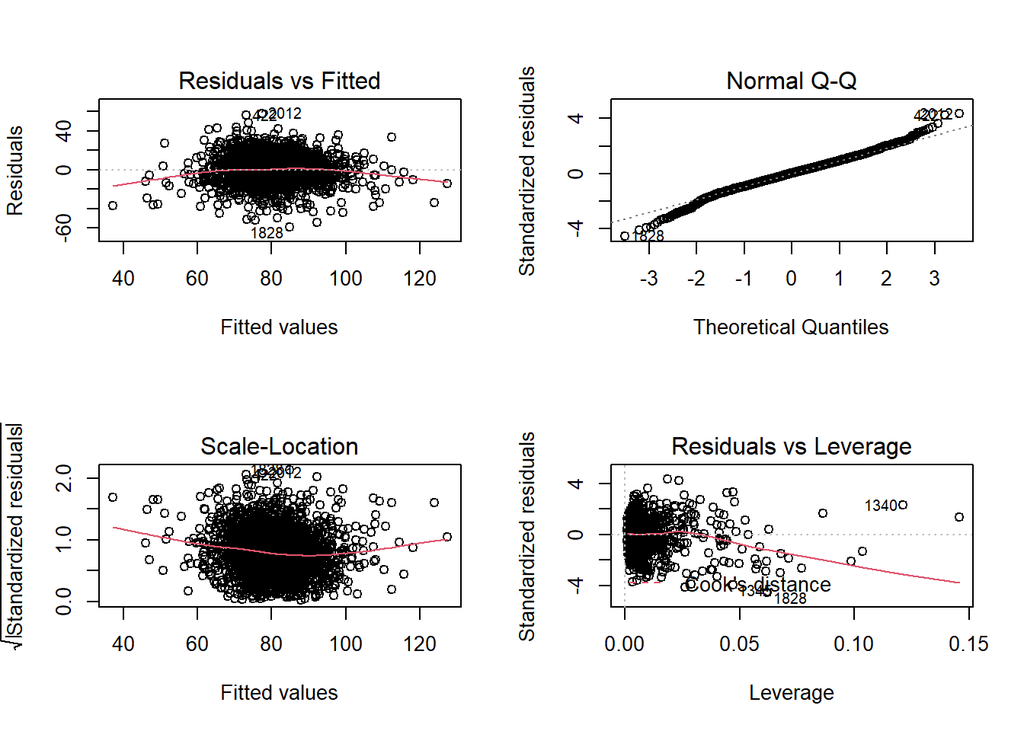

```r
# Plot results
par(mfrow=c(2,2))
plot(m1)
```

##### **Model 2: Log transformation**

Note: Model 2 was not a successful model compared to model 1. There weren’t any significant changes between the two models therefore discarding this model.

```r
# Checking skewness of dataset
sapply(baseball_df_final, function(x) skewness(x)) %>%
  kable() %>%
  kable_styling(bootstrap_options = c("striped", "hover", "condensed"), font_size = 13)
```

|  | x |
| --- | --- |
| INDEX | 0.0042149 |
| TARGET_WINS | -0.3987232 |
| TEAM_BATTING_H | 1.5713335 |
| TEAM_BATTING_2B | 0.2151018 |
| TEAM_BATTING_3B | 1.1094652 |
| TEAM_BATTING_HR | 0.1860421 |
| TEAM_BATTING_BB | -1.0257599 |
| TEAM_BATTING_SO | -0.2258649 |
| TEAM_BASERUN_SB | 1.8607589 |
| TEAM_PITCHING_H | 3.3490180 |
| TEAM_PITCHING_HR | 0.2877877 |
| TEAM_PITCHING_BB | -2.4931634 |
| TEAM_PITCHING_SO | -0.0237076 |
| TEAM_FIELDING_E | 2.1084199 |

```r
# Doing log transformations from model 1
baseball_df_final_log <- baseball_df_final

# Applying log transformation for highly skewed variables
baseball_df_final_log$TEAM_BATTING_H <- log10(baseball_df_final_log$TEAM_BATTING_H + 1)
baseball_df_final_log$TEAM_BATTING_2B <- log10(baseball_df_final_log$TEAM_BATTING_2B + 1)
baseball_df_final_log$TEAM_PITCHING_H <- log10(baseball_df_final_log$TEAM_PITCHING_H + 1)
baseball_df_final_log$TEAM_PITCHING_BB <- log10(baseball_df_final_log$TEAM_PITCHING_BB + 1)
baseball_df_final_log$TEAM_FIELDING_E <- log10(baseball_df_final_log$TEAM_FIELDING_E + 1)
baseball_df_final_log$TEAM_BASERUN_SB <- log10(baseball_df_final_log$TEAM_BASERUN_SB + 1)

# Checking skewness
sapply(baseball_df_final_log, function(x) skewness(x)) %>%
  kable() %>%
  kable_styling(bootstrap_options = c("striped", "hover", "condensed"), font_size = 13)
```

|  | x |
| --- | --- |
| INDEX | 0.0042149 |
| TARGET_WINS | -0.3987232 |
| TEAM_BATTING_H | 0.7835017 |
| TEAM_BATTING_2B | -0.4041236 |
| TEAM_BATTING_3B | 1.1094652 |
| TEAM_BATTING_HR | 0.1860421 |
| TEAM_BATTING_BB | -1.0257599 |
| TEAM_BATTING_SO | -0.2258649 |
| TEAM_BASERUN_SB | -0.1466066 |
| TEAM_PITCHING_H | 2.1429864 |
| TEAM_PITCHING_HR | 0.2877877 |
| TEAM_PITCHING_BB | -13.6001569 |
| TEAM_PITCHING_SO | -0.0237076 |
| TEAM_FIELDING_E | 1.0877139 |

```r
# Model 2 log
m2 <- lm(TARGET_WINS ~., data = baseball_df_final_log, na.action = na.omit)

#Summary
summ(m2)
```

| Observations | 2276 |
| --- | --- |
| Dependent variable | TARGET_WINS |
| Type | OLS linear regression |

| F(13,2262) | 69.80 |
| --- | --- |
| R² | 0.29 |
| Adj. R² | 0.28 |

|  | Est. | S.E. | t val. | p |
| --- | --- | --- | --- | --- |
| (Intercept) | -291.04 | 37.37 | -7.79 | 0.00 |
| INDEX | -0.00 | 0.00 | -1.64 | 0.10 |
| TEAM_BATTING_H | 111.79 | 13.71 | 8.16 | 0.00 |
| TEAM_BATTING_2B | -5.99 | 5.26 | -1.14 | 0.25 |
| TEAM_BATTING_3B | 0.11 | 0.02 | 6.02 | 0.00 |
| TEAM_BATTING_HR | 0.09 | 0.03 | 3.41 | 0.00 |
| TEAM_BATTING_BB | 0.03 | 0.00 | 8.57 | 0.00 |
| TEAM_BATTING_SO | -0.00 | 0.00 | -0.15 | 0.88 |
| TEAM_BASERUN_SB | 13.72 | 1.25 | 10.94 | 0.00 |
| TEAM_PITCHING_H | 8.57 | 5.82 | 1.47 | 0.14 |
| TEAM_PITCHING_HR | -0.03 | 0.02 | -1.36 | 0.17 |
| TEAM_PITCHING_BB | -2.12 | 4.27 | -0.50 | 0.62 |
| TEAM_PITCHING_SO | -0.01 | 0.00 | -1.96 | 0.05 |
| TEAM_FIELDING_E | -17.02 | 2.30 | -7.40 | 0.00 |

Standard errors: OLS

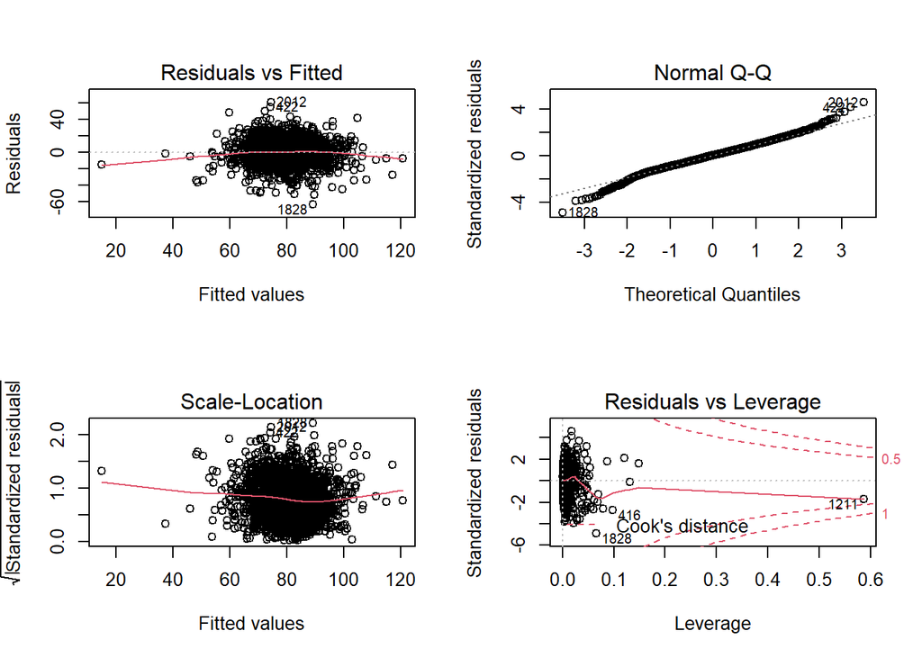

```r
# Plot results
par(mfrow=c(2,2))
plot(m2)
```

$~$

##### **Model 3: Statistically significant**

Focusing on statistically significant values chosen primarily from their R output.

```r
# Model 3
m3 <- lm(TARGET_WINS ~ TEAM_BATTING_H + TEAM_BATTING_3B + TEAM_BATTING_HR + TEAM_BATTING_BB + TEAM_BASERUN_SB + TEAM_FIELDING_E, data = baseball_df_final)

# Summary
summ(m3)
```

| Observations | 2276 |
| --- | --- |
| Dependent variable | TARGET_WINS |
| Type | OLS linear regression |

| F(6,2269) | 141.91 |
| --- | --- |
| R² | 0.27 |
| Adj. R² | 0.27 |

|  | Est. | S.E. | t val. | p |
| --- | --- | --- | --- | --- |
| (Intercept) | 1.35 | 3.39 | 0.40 | 0.69 |
| TEAM_BATTING_H | 0.04 | 0.00 | 14.87 | 0.00 |
| TEAM_BATTING_3B | 0.09 | 0.02 | 5.29 | 0.00 |
| TEAM_BATTING_HR | 0.05 | 0.01 | 5.94 | 0.00 |
| TEAM_BATTING_BB | 0.03 | 0.00 | 12.26 | 0.00 |
| TEAM_BASERUN_SB | 0.04 | 0.00 | 10.56 | 0.00 |
| TEAM_FIELDING_E | -0.02 | 0.00 | -6.51 | 0.00 |

Standard errors: OLS

```r
# par(mfrow=c(2,2))
# plot(m3)
```

$~$

##### **Model 4: Backwards Elimination**

Variables that are not statistically significant are removed to determine a best fit model.

```r
# Model 4
m4 <- lm(TARGET_WINS ~ TEAM_BATTING_2B + TEAM_PITCHING_H +  TEAM_PITCHING_HR +  TEAM_PITCHING_BB + TEAM_PITCHING_SO, data = baseball_df_final)

# Summary
summ(m4)
```

| Observations | 2276 |
| --- | --- |
| Dependent variable | TARGET_WINS |
| Type | OLS linear regression |

| F(5,2270) | 82.61 |
| --- | --- |
| R² | 0.15 |
| Adj. R² | 0.15 |

|  | Est. | S.E. | t val. | p |
| --- | --- | --- | --- | --- |
| (Intercept) | 44.79 | 3.44 | 13.01 | 0.00 |
| TEAM_BATTING_2B | 0.06 | 0.01 | 7.19 | 0.00 |
| TEAM_PITCHING_H | 0.01 | 0.00 | 8.09 | 0.00 |
| TEAM_PITCHING_HR | 0.06 | 0.01 | 8.65 | 0.00 |
| TEAM_PITCHING_BB | 0.03 | 0.01 | 6.09 | 0.00 |
| TEAM_PITCHING_SO | -0.02 | 0.00 | -9.97 | 0.00 |

Standard errors: OLS

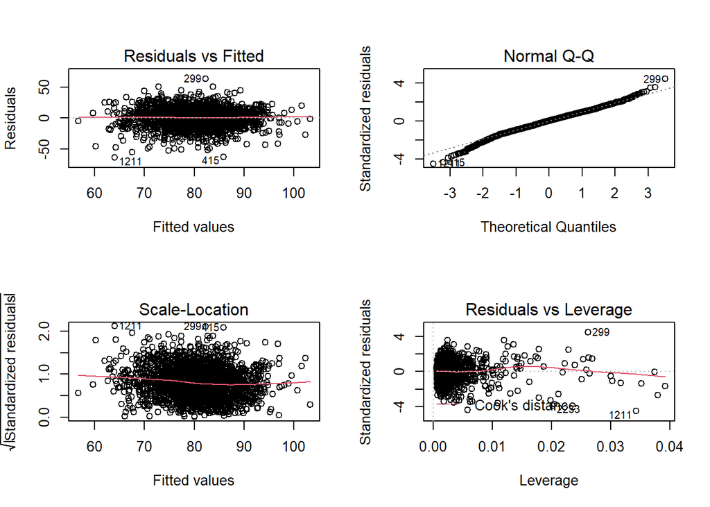

```r
# Plot results
par(mfrow=c(2,2))
plot(m4)
```

$~$

##### **Model 5 - Power**

Using a power model may be more effective considering each independent variable doesn’t appear to have a truly linear relationship with wins. Here we create a model using a cubit for each independent variable.

```r
# Model 5
m5 <- lm(TARGET_WINS ~ TEAM_BATTING_H + I(TEAM_BATTING_H^2) + I(TEAM_BATTING_H^3) +
           TEAM_BATTING_2B + I(TEAM_BATTING_2B^2) + I(TEAM_BATTING_2B^3) +
           TEAM_BATTING_3B + I(TEAM_BATTING_3B^2) + I(TEAM_BATTING_3B^3) +
           TEAM_BATTING_HR + I(TEAM_BATTING_HR^2) + I(TEAM_BATTING_HR^3) +
           TEAM_BATTING_BB + I(TEAM_BATTING_BB^2) + I(TEAM_BATTING_BB^3) +
           TEAM_BATTING_SO + I(TEAM_BATTING_SO^2) + I(TEAM_BATTING_SO^3) +
           TEAM_BASERUN_SB + I(TEAM_BASERUN_SB^2) + I(TEAM_BASERUN_SB^3) +
           TEAM_PITCHING_H + I(TEAM_PITCHING_H^2) + I(TEAM_PITCHING_H^3) +
           TEAM_PITCHING_HR + I(TEAM_PITCHING_HR^2) + I(TEAM_PITCHING_HR^3) +
           TEAM_PITCHING_BB + I(TEAM_PITCHING_BB^2) + I(TEAM_PITCHING_BB^3) +
           TEAM_PITCHING_SO + I(TEAM_PITCHING_SO^2) + I(TEAM_PITCHING_SO^3) +
           TEAM_FIELDING_E + I(TEAM_FIELDING_E^2) + I(TEAM_FIELDING_E^3), data = baseball_df_final)

# Summary
summ(m5)
```

| Observations | 2276 |
| --- | --- |
| Dependent variable | TARGET_WINS |
| Type | OLS linear regression |

| F(36,2239) | 35.78 |
| --- | --- |
| R² | 0.37 |
| Adj. R² | 0.35 |

|  | Est. | S.E. | t val. | p |
| --- | --- | --- | --- | --- |
| (Intercept) | -13.91 | 64.05 | -0.22 | 0.83 |
| TEAM_BATTING_H | 0.07 | 0.13 | 0.53 | 0.59 |
| I(TEAM_BATTING_H^2) | -0.00 | 0.00 | -0.26 | 0.80 |
| I(TEAM_BATTING_H^3) | 0.00 | 0.00 | 0.41 | 0.68 |
| TEAM_BATTING_2B | 1.05 | 0.20 | 5.32 | 0.00 |
| I(TEAM_BATTING_2B^2) | -0.00 | 0.00 | -5.29 | 0.00 |
| I(TEAM_BATTING_2B^3) | 0.00 | 0.00 | 5.11 | 0.00 |
| TEAM_BATTING_3B | -0.04 | 0.09 | -0.44 | 0.66 |
| I(TEAM_BATTING_3B^2) | 0.00 | 0.00 | 2.76 | 0.01 |
| I(TEAM_BATTING_3B^3) | -0.00 | 0.00 | -3.98 | 0.00 |
| TEAM_BATTING_HR | 0.16 | 0.14 | 1.15 | 0.25 |
| I(TEAM_BATTING_HR^2) | -0.00 | 0.00 | -1.11 | 0.27 |
| I(TEAM_BATTING_HR^3) | 0.00 | 0.00 | 0.84 | 0.40 |
| TEAM_BATTING_BB | 0.21 | 0.05 | 4.15 | 0.00 |
| I(TEAM_BATTING_BB^2) | -0.00 | 0.00 | -3.45 | 0.00 |
| I(TEAM_BATTING_BB^3) | 0.00 | 0.00 | 3.26 | 0.00 |
| TEAM_BATTING_SO | 0.11 | 0.03 | 3.47 | 0.00 |
| I(TEAM_BATTING_SO^2) | -0.00 | 0.00 | -2.83 | 0.00 |
| I(TEAM_BATTING_SO^3) | 0.00 | 0.00 | 1.96 | 0.05 |
| TEAM_BASERUN_SB | 0.08 | 0.02 | 4.46 | 0.00 |
| I(TEAM_BASERUN_SB^2) | -0.00 | 0.00 | -1.21 | 0.23 |
| I(TEAM_BASERUN_SB^3) | 0.00 | 0.00 | 0.30 | 0.77 |
| TEAM_PITCHING_H | -0.13 | 0.03 | -4.36 | 0.00 |
| I(TEAM_PITCHING_H^2) | 0.00 | 0.00 | 3.89 | 0.00 |
| I(TEAM_PITCHING_H^3) | -0.00 | 0.00 | -3.30 | 0.00 |
| TEAM_PITCHING_HR | -0.34 | 0.12 | -2.75 | 0.01 |
| I(TEAM_PITCHING_HR^2) | 0.00 | 0.00 | 3.77 | 0.00 |
| I(TEAM_PITCHING_HR^3) | -0.00 | 0.00 | -3.87 | 0.00 |
| TEAM_PITCHING_BB | 0.10 | 0.11 | 0.92 | 0.36 |
| I(TEAM_PITCHING_BB^2) | -0.00 | 0.00 | -1.71 | 0.09 |
| I(TEAM_PITCHING_BB^3) | 0.00 | 0.00 | 2.01 | 0.04 |
| TEAM_PITCHING_SO | -0.07 | 0.02 | -2.88 | 0.00 |
| I(TEAM_PITCHING_SO^2) | 0.00 | 0.00 | 2.36 | 0.02 |
| I(TEAM_PITCHING_SO^3) | -0.00 | 0.00 | -2.22 | 0.03 |
| TEAM_FIELDING_E | -0.14 | 0.04 | -3.53 | 0.00 |
| I(TEAM_FIELDING_E^2) | 0.00 | 0.00 | 1.51 | 0.13 |
| I(TEAM_FIELDING_E^3) | -0.00 | 0.00 | -0.38 | 0.71 |

Standard errors: OLS

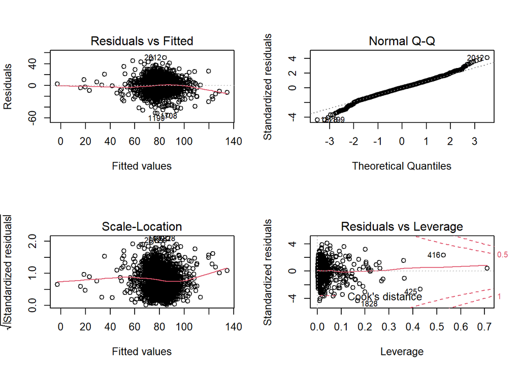

```r
# Plot results
par(mfrow=c(2,2))
plot(m5)
```

##### **Model 6 - Power with Reverse Elimination**

```r
# Model 6
m6 <- lm(TARGET_WINS ~ TEAM_BATTING_H +
           TEAM_BATTING_2B + I(TEAM_BATTING_2B^2) + I(TEAM_BATTING_2B^3) +
           I(TEAM_BATTING_3B^2) + I(TEAM_BATTING_3B^3) +
           TEAM_BATTING_BB + I(TEAM_BATTING_BB^2) + I(TEAM_BATTING_BB^3) +
           TEAM_BATTING_SO + I(TEAM_BATTING_SO^2) +
           TEAM_BASERUN_SB + I(TEAM_BASERUN_SB^2) +
           TEAM_PITCHING_H + I(TEAM_PITCHING_H^2) + I(TEAM_PITCHING_H^3) +
           TEAM_PITCHING_HR + I(TEAM_PITCHING_HR^2) + I(TEAM_PITCHING_HR^3) +
           I(TEAM_PITCHING_BB^2) + I(TEAM_PITCHING_BB^3) +
           TEAM_PITCHING_SO + I(TEAM_PITCHING_SO^2) + I(TEAM_PITCHING_SO^3) +
           TEAM_FIELDING_E + I(TEAM_FIELDING_E^2), data = baseball_df_final)

# Summary
summ(m6)
```

| Observations | 2276 |
| --- | --- |
| Dependent variable | TARGET_WINS |
| Type | OLS linear regression |

| F(26,2249) | 49.21 |
| --- | --- |
| R² | 0.36 |
| Adj. R² | 0.36 |

|  | Est. | S.E. | t val. | p |
| --- | --- | --- | --- | --- |
| (Intercept) | 6.69 | 23.75 | 0.28 | 0.78 |
| TEAM_BATTING_H | 0.05 | 0.00 | 13.00 | 0.00 |
| TEAM_BATTING_2B | 1.03 | 0.19 | 5.37 | 0.00 |
| I(TEAM_BATTING_2B^2) | -0.00 | 0.00 | -5.35 | 0.00 |
| I(TEAM_BATTING_2B^3) | 0.00 | 0.00 | 5.19 | 0.00 |
| I(TEAM_BATTING_3B^2) | 0.00 | 0.00 | 8.13 | 0.00 |
| I(TEAM_BATTING_3B^3) | -0.00 | 0.00 | -7.65 | 0.00 |
| TEAM_BATTING_BB | 0.27 | 0.05 | 5.75 | 0.00 |
| I(TEAM_BATTING_BB^2) | -0.00 | 0.00 | -4.63 | 0.00 |
| I(TEAM_BATTING_BB^3) | 0.00 | 0.00 | 4.22 | 0.00 |
| TEAM_BATTING_SO | 0.06 | 0.01 | 4.41 | 0.00 |
| I(TEAM_BATTING_SO^2) | -0.00 | 0.00 | -5.43 | 0.00 |
| TEAM_BASERUN_SB | 0.08 | 0.01 | 8.37 | 0.00 |
| I(TEAM_BASERUN_SB^2) | -0.00 | 0.00 | -4.35 | 0.00 |
| TEAM_PITCHING_H | -0.14 | 0.03 | -5.58 | 0.00 |
| I(TEAM_PITCHING_H^2) | 0.00 | 0.00 | 5.02 | 0.00 |
| I(TEAM_PITCHING_H^3) | -0.00 | 0.00 | -4.35 | 0.00 |
| TEAM_PITCHING_HR | -0.19 | 0.04 | -4.67 | 0.00 |
| I(TEAM_PITCHING_HR^2) | 0.00 | 0.00 | 6.14 | 0.00 |
| I(TEAM_PITCHING_HR^3) | -0.00 | 0.00 | -5.56 | 0.00 |
| I(TEAM_PITCHING_BB^2) | -0.00 | 0.00 | -3.20 | 0.00 |
| I(TEAM_PITCHING_BB^3) | 0.00 | 0.00 | 2.90 | 0.00 |
| TEAM_PITCHING_SO | -0.04 | 0.02 | -2.32 | 0.02 |
| I(TEAM_PITCHING_SO^2) | 0.00 | 0.00 | 1.50 | 0.13 |
| I(TEAM_PITCHING_SO^3) | -0.00 | 0.00 | -1.23 | 0.22 |
| TEAM_FIELDING_E | -0.12 | 0.02 | -7.76 | 0.00 |
| I(TEAM_FIELDING_E^2) | 0.00 | 0.00 | 6.40 | 0.00 |

Standard errors: OLS

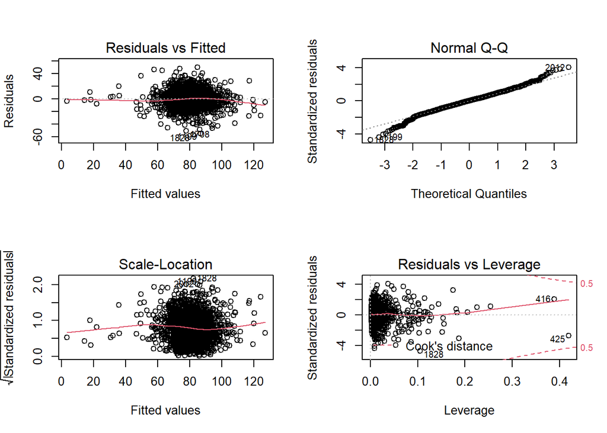

```r
# Plot results
par(mfrow=c(2,2))
plot(m6)
```

#### ** Automated Reverse Elimination **

Based on residual analysis, all six models produced residuals that are heteroschedastic and not normally distributed. Therefore, we tried a different approach and ran the model without imputation and without transformation. We performed backwards elimination using an automated function to generate a new function call based on removing the parameter with the highest p-value (see Appendix A for R code and full model results).

```r
# Initialize list to store model results
lmlist <- vector(mode='list', length=0)

# Build model call, start with full model (without index field)
model_params <- 'TARGET_WINS ~ . - INDEX'

# Iterate until p-values are less than 0.05
while (T) {

  # Lengthen the model results list
  i <- length(lmlist)
  i <- i + 1
  length(lmlist) <- i
  print('-----------------------------------------------------------')
  print(model_params)

  # Run the model
  lmlist[[i]] <- lm(model_params, train_df, na.action=na.exclude)
  lmsum <- summary(lmlist[[i]])
  print(summ(lmlist[[i]]))

  # Get the p-values in descending order, check to see if it's less than 0.05
  pvals <- sort(lmsum$coefficients[,4], decreasing=T)
  if (pvals[1] <= 0.05) {

    # Break out of the while loop because the largest p-value is statistically significant
    break

  } else {

    # Find the column with the highest p-value
    remove_col <- names(pvals[1])

    # Change the model call, removing the column with the highest p-value
    model_params <- paste0(model_params, ' - ', remove_col)

  }
}
```

```
## [1] "-----------------------------------------------------------"
## [1] "TARGET_WINS ~ . - INDEX"
## MODEL INFO:
## Observations: 191 (2085 missing obs. deleted)
## Dependent Variable: TARGET_WINS
## Type: OLS linear regression
##
## MODEL FIT:
## F(15,175) = 14.27, p = 0.00
## R² = 0.55
## Adj. R² = 0.51
##
## Standard errors: OLS
## ------------------------------------------------------
##                           Est.    S.E.   t val.      p
## ---------------------- ------- ------- -------- ------
## (Intercept)              60.29   19.68     3.06   0.00
## TEAM_BATTING_H            1.91    2.76     0.69   0.49
## TEAM_BATTING_2B           0.03    0.03     0.87   0.38
## TEAM_BATTING_3B          -0.10    0.08    -1.31   0.19
## TEAM_BATTING_HR          -4.84   10.51    -0.46   0.65
## TEAM_BATTING_BB          -4.46    3.64    -1.23   0.22
## TEAM_BATTING_SO           0.34    2.60     0.13   0.90
## TEAM_BASERUN_SB           0.03    0.03     1.15   0.25
## TEAM_BASERUN_CS          -0.01    0.07    -0.15   0.88
## TEAM_BATTING_HBP          0.08    0.05     1.66   0.10
## TEAM_PITCHING_H          -1.89    2.76    -0.68   0.49
## TEAM_PITCHING_HR          4.93   10.51     0.47   0.64
## TEAM_PITCHING_BB          4.51    3.63     1.24   0.22
## TEAM_PITCHING_SO         -0.37    2.60    -0.14   0.89
## TEAM_FIELDING_E          -0.17    0.04    -4.16   0.00
## TEAM_FIELDING_DP         -0.11    0.04    -2.96   0.00
## ------------------------------------------------------
## [1] "-----------------------------------------------------------"
## [1] "TARGET_WINS ~ . - INDEX - TEAM_BATTING_SO"
## MODEL INFO:
## Observations: 191 (2085 missing obs. deleted)
## Dependent Variable: TARGET_WINS
## Type: OLS linear regression
##
```

[output cut: 230 more lines]

```
## R² = 0.53
## Adj. R² = 0.51
##
## Standard errors: OLS
## ------------------------------------------------------
##                           Est.    S.E.   t val.      p
## ---------------------- ------- ------- -------- ------
## (Intercept)              63.47   19.17     3.31   0.00
## TEAM_BATTING_H            0.03    0.01     2.54   0.01
## TEAM_PITCHING_HR          0.09    0.02     3.81   0.00
## TEAM_PITCHING_BB          0.06    0.01     5.93   0.00
## TEAM_PITCHING_SO         -0.03    0.01    -4.02   0.00
## TEAM_FIELDING_E          -0.17    0.04    -4.36   0.00
## TEAM_FIELDING_DP         -0.12    0.04    -3.44   0.00
## ------------------------------------------------------
```

### **Model Selection**

First, create functions to calculate mean squared error and perform model analysis given a linear model.

```r
# Define function to calculate mean squared error
mse <- function(lmod) {
  return(mean((summary(lmod))$residuals ^ 2))
}

# Define function to aid in model analysis
ModelAnalysis <- function(lmod, x) {

  # Plot residuals
  print('--------------------------------------------------')
  print(lmod$call)
  par(mfrow=c(2,2))
  plot(lmod)

  # Shapiro test to determine normality of residuals
  # null hypothesis: the residuals are normal
  # p-value is small, so reject the null
  # i.e., the residuals are not normal
  st <- shapiro.test(lmod$residuals)
  if (st$p.value <= 0.05) {
    print(paste0("Shapiro test for normality: The p-value of ", st$p.value, " is <= 0.05, so reject the null; i.e., the residuals are NOT normal."))
  } else {
    print(paste0("Shapiro test for normality: The p-value of ", st$p.value, " is > 0.05, so do not reject the null; i.e., the residuals are normal."))
  }

  # Breusch-Pagan test to determine homoschedasticity of residuals
  bp <- bptest(lmod)
  if (bp$p.value > 0.05 & bp$statistic < 10) {
      print(paste0("Breusch-Pagan test for homoschedasticity: The p-value of ", bp$p.value, " is > 0.05 and the test statistic of ", bp$statistic,
          " is < 10, so don't reject the null; i.e., the residuals are homoschedastic."))
  } else if (bp$p.value <= 0.05) {
      print(paste0("Breusch-Pagan test for homoschedasticity: The p-value of ", bp$p.value, " is <= 0.05 and the test statistic is ", bp$statistic,
          ", so reject the null; i.e., the residuals are heteroschedastic."))
  } else {
      print(paste0("Breusch-Pagan test for homoschedasticity: The p-value of ", bp$p.value, " and test statistic of ", bp$statistic,
          " are inconclusive, so homoschedasticity can't be determined using this test."))
  }

  # Adjusted R-squared
  print(paste0('Adjusted R-squared value: ', (summary(lmod)$adj.r.squared)))

  # Mean squared error
  m <- mse(lmod)
  print(paste0('Mean squared error: ', mse(lmod)))

}
```

Model analysis on each of the 6 models.

```r
# Model analysis
ModelAnalysis(m1)
```

```
## [1] "--------------------------------------------------"
## lm(formula = TARGET_WINS ~ ., data = baseball_df_final, na.action = na.omit)
```

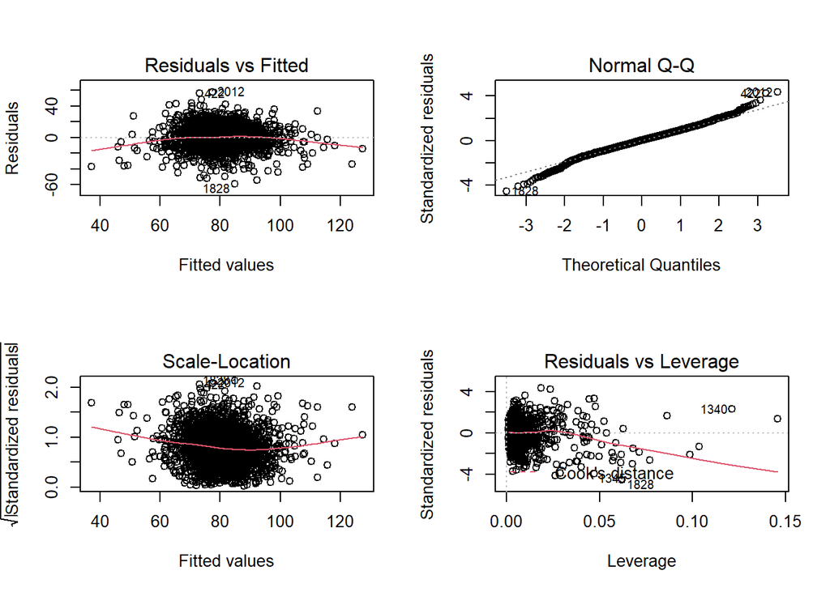

```
## [1] "Shapiro test for normality: The p-value of 1.04556378279577e-10 is <= 0.05, so reject the null; i.e., the residuals are NOT normal."
## [1] "Breusch-Pagan test for homoschedasticity: The p-value of 7.02419507641643e-59 is <= 0.05 and the test statistic is 312.104580852486, so reject the null; i.e., the residuals are heteroschedastic."
## [1] "Adjusted R-squared value: 0.279067578558492"
## [1] "Mean squared error: 177.784835300702"
```

```r
ModelAnalysis(m2)
```

```
## [1] "--------------------------------------------------"
## lm(formula = TARGET_WINS ~ ., data = baseball_df_final_log, na.action = na.omit)
```

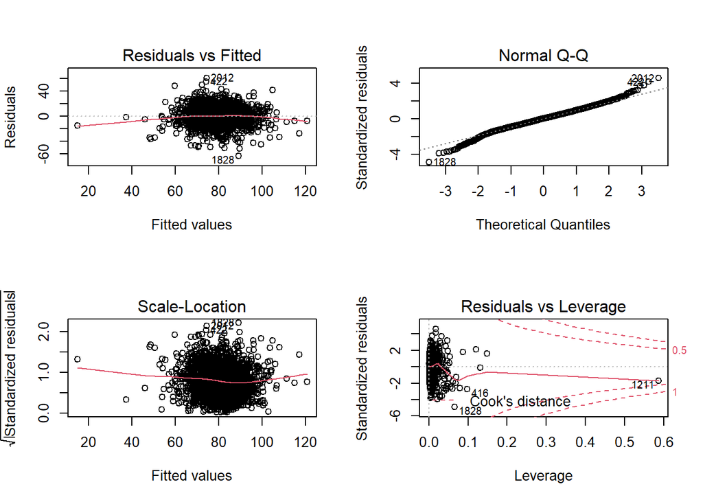

```
## [1] "Shapiro test for normality: The p-value of 7.305674163284e-11 is <= 0.05, so reject the null; i.e., the residuals are NOT normal."
## [1] "Breusch-Pagan test for homoschedasticity: The p-value of 4.06673586911508e-56 is <= 0.05 and the test statistic is 298.910144956467, so reject the null; i.e., the residuals are heteroschedastic."
## [1] "Adjusted R-squared value: 0.282197596618816"
## [1] "Mean squared error: 177.012960255562"
```

```r
ModelAnalysis(m3)
```

```
## [1] "--------------------------------------------------"
## lm(formula = TARGET_WINS ~ TEAM_BATTING_H + TEAM_BATTING_3B +
##     TEAM_BATTING_HR + TEAM_BATTING_BB + TEAM_BASERUN_SB + TEAM_FIELDING_E,
##     data = baseball_df_final)
```

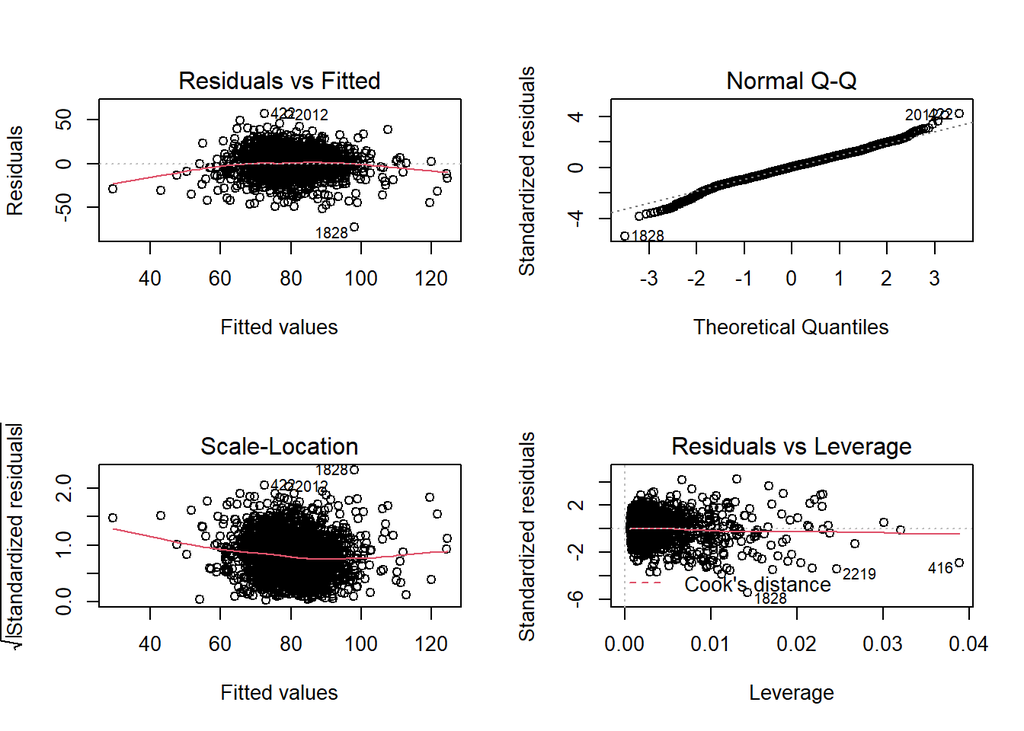

```
## [1] "Shapiro test for normality: The p-value of 3.41098138059316e-11 is <= 0.05, so reject the null; i.e., the residuals are NOT normal."
## [1] "Breusch-Pagan test for homoschedasticity: The p-value of 8.38203287406739e-55 is <= 0.05 and the test statistic is 267.256057804979, so reject the null; i.e., the residuals are heteroschedastic."
## [1] "Adjusted R-squared value: 0.270945335482595"
## [1] "Mean squared error: 180.344185660252"
```

```r
ModelAnalysis(m4)
```

```
## [1] "--------------------------------------------------"
## lm(formula = TARGET_WINS ~ TEAM_BATTING_2B + TEAM_PITCHING_H +
##     TEAM_PITCHING_HR + TEAM_PITCHING_BB + TEAM_PITCHING_SO, data = baseball_df_final)
```

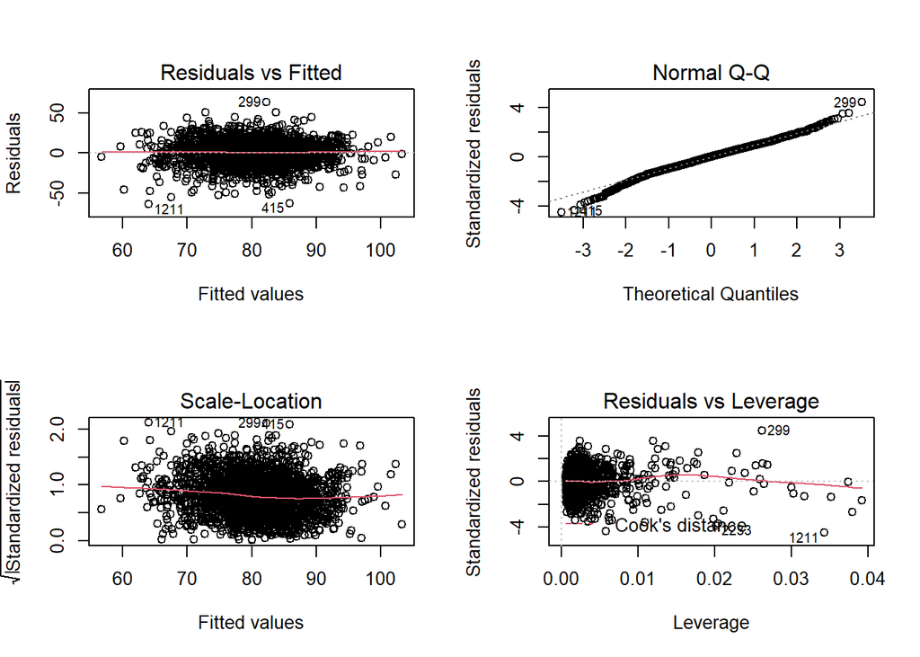

```
## [1] "Shapiro test for normality: The p-value of 6.56700377590433e-10 is <= 0.05, so reject the null; i.e., the residuals are NOT normal."
## [1] "Breusch-Pagan test for homoschedasticity: The p-value of 2.21852754767312e-44 is <= 0.05 and the test statistic is 214.518079436075, so reject the null; i.e., the residuals are heteroschedastic."
## [1] "Adjusted R-squared value: 0.152084762048857"
## [1] "Mean squared error: 209.838828780989"
```

```r
ModelAnalysis(m5)
```

```
## [1] "--------------------------------------------------"
## lm(formula = TARGET_WINS ~ TEAM_BATTING_H + I(TEAM_BATTING_H^2) +
##     I(TEAM_BATTING_H^3) + TEAM_BATTING_2B + I(TEAM_BATTING_2B^2) +
##     I(TEAM_BATTING_2B^3) + TEAM_BATTING_3B + I(TEAM_BATTING_3B^2) +
##     I(TEAM_BATTING_3B^3) + TEAM_BATTING_HR + I(TEAM_BATTING_HR^2) +
##     I(TEAM_BATTING_HR^3) + TEAM_BATTING_BB + I(TEAM_BATTING_BB^2) +
##     I(TEAM_BATTING_BB^3) + TEAM_BATTING_SO + I(TEAM_BATTING_SO^2) +
##     I(TEAM_BATTING_SO^3) + TEAM_BASERUN_SB + I(TEAM_BASERUN_SB^2) +
##     I(TEAM_BASERUN_SB^3) + TEAM_PITCHING_H + I(TEAM_PITCHING_H^2) +
##     I(TEAM_PITCHING_H^3) + TEAM_PITCHING_HR + I(TEAM_PITCHING_HR^2) +
##     I(TEAM_PITCHING_HR^3) + TEAM_PITCHING_BB + I(TEAM_PITCHING_BB^2) +
##     I(TEAM_PITCHING_BB^3) + TEAM_PITCHING_SO + I(TEAM_PITCHING_SO^2) +
##     I(TEAM_PITCHING_SO^3) + TEAM_FIELDING_E + I(TEAM_FIELDING_E^2) +
##     I(TEAM_FIELDING_E^3), data = baseball_df_final)
```

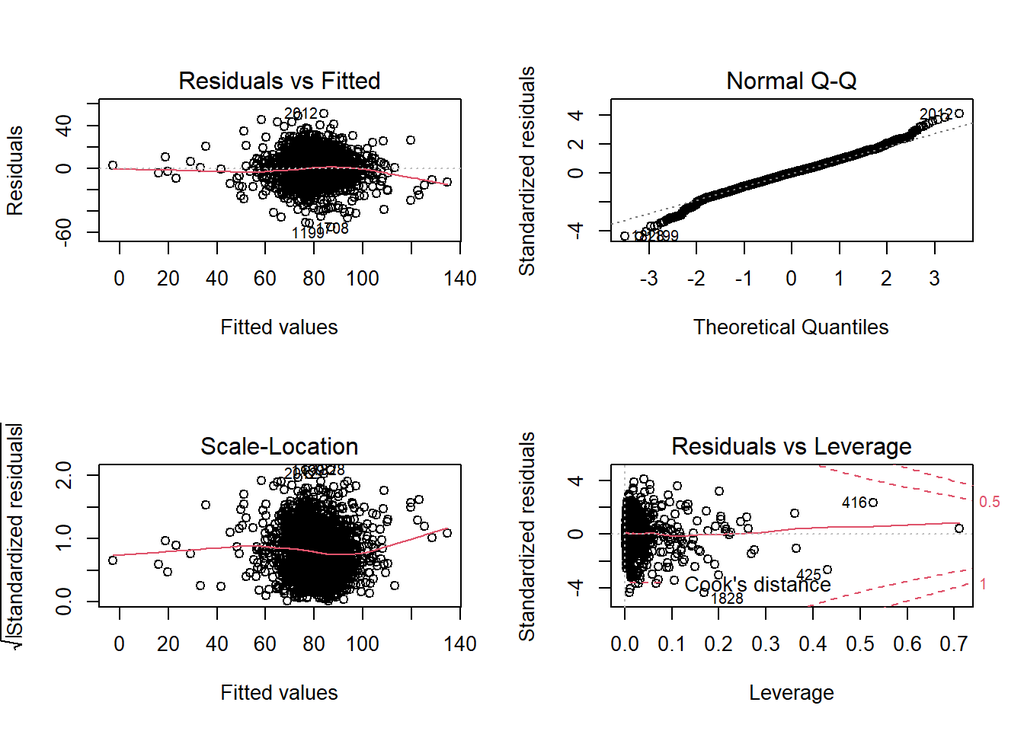

```
## [1] "Shapiro test for normality: The p-value of 5.98340064191167e-10 is <= 0.05, so reject the null; i.e., the residuals are NOT normal."
## [1] "Breusch-Pagan test for homoschedasticity: The p-value of 1.52321013284566e-46 is <= 0.05 and the test statistic is 316.380936352325, so reject the null; i.e., the residuals are heteroschedastic."
## [1] "Adjusted R-squared value: 0.354968093291786"
## [1] "Mean squared error: 157.450066195233"
```

```r
ModelAnalysis(m6)
```

```
## [1] "--------------------------------------------------"
## lm(formula = TARGET_WINS ~ TEAM_BATTING_H + TEAM_BATTING_2B +
##     I(TEAM_BATTING_2B^2) + I(TEAM_BATTING_2B^3) + I(TEAM_BATTING_3B^2) +
##     I(TEAM_BATTING_3B^3) + TEAM_BATTING_BB + I(TEAM_BATTING_BB^2) +
##     I(TEAM_BATTING_BB^3) + TEAM_BATTING_SO + I(TEAM_BATTING_SO^2) +
##     TEAM_BASERUN_SB + I(TEAM_BASERUN_SB^2) + TEAM_PITCHING_H +
##     I(TEAM_PITCHING_H^2) + I(TEAM_PITCHING_H^3) + TEAM_PITCHING_HR +
##     I(TEAM_PITCHING_HR^2) + I(TEAM_PITCHING_HR^3) + I(TEAM_PITCHING_BB^2) +
##     I(TEAM_PITCHING_BB^3) + TEAM_PITCHING_SO + I(TEAM_PITCHING_SO^2) +
##     I(TEAM_PITCHING_SO^3) + TEAM_FIELDING_E + I(TEAM_FIELDING_E^2),
##     data = baseball_df_final)
```

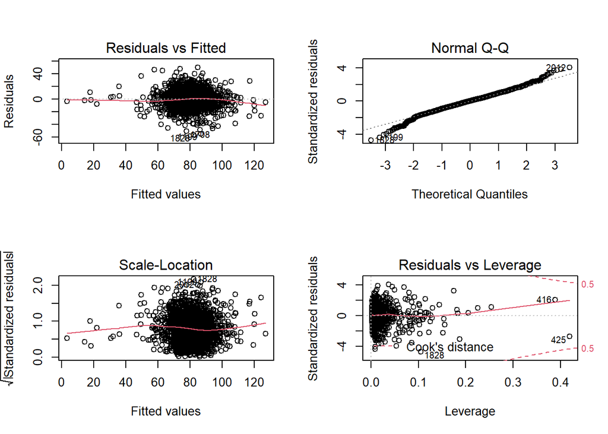

```
## [1] "Shapiro test for normality: The p-value of 1.7370518083911e-10 is <= 0.05, so reject the null; i.e., the residuals are NOT normal."
## [1] "Breusch-Pagan test for homoschedasticity: The p-value of 1.35597031615975e-41 is <= 0.05 and the test statistic is 265.763199270119, so reject the null; i.e., the residuals are heteroschedastic."
## [1] "Adjusted R-squared value: 0.355219801227876"
## [1] "Mean squared error: 158.091566759293"
```

```r
for (i in seq(1:length(lmlist))) {
  ModelAnalysis(lmlist[[i]])
}
```

```
## [1] "--------------------------------------------------"
## lm(formula = model_params, data = train_df, na.action = na.exclude)
```

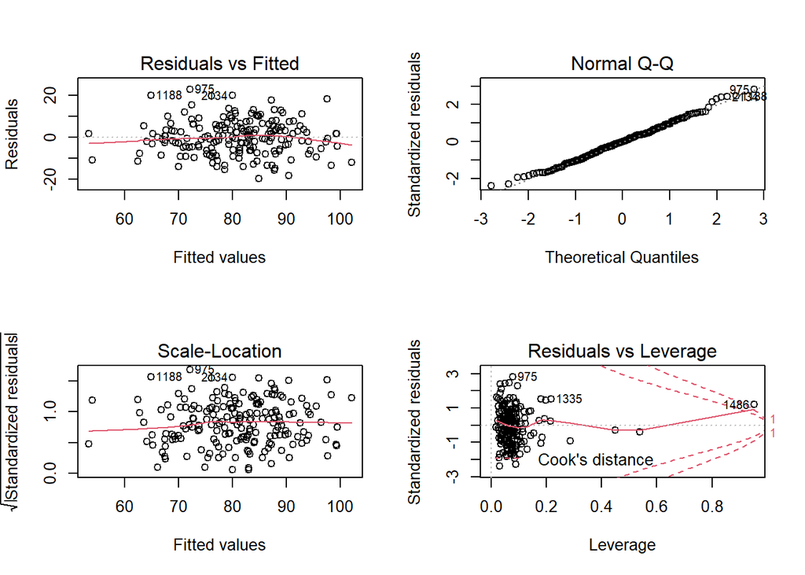

```
## [1] "Shapiro test for normality: The p-value of 0.68635315935079 is > 0.05, so do not reject the null; i.e., the residuals are normal."
## [1] "Breusch-Pagan test for homoschedasticity: The p-value of 0.910493611472761 is > 0.05 and the test statistic of 8.31591414524163 is < 10, so don't reject the null; i.e., the residuals are homoschedastic."
## [1] "Adjusted R-squared value: 0.51155503324235"
## [1] "Mean squared error: 65.6852879651226"
## [1] "--------------------------------------------------"
## lm(formula = model_params, data = train_df, na.action = na.exclude)
```

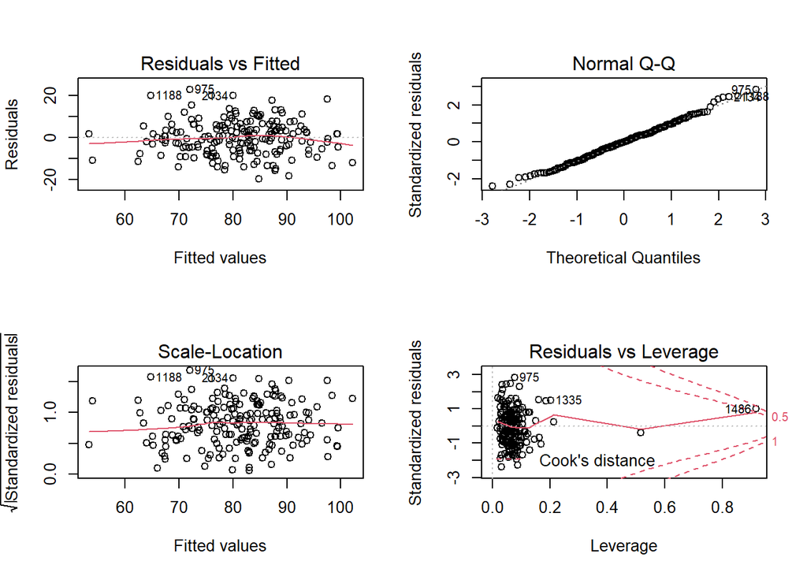

```
## [1] "Shapiro test for normality: The p-value of 0.68069919601348 is > 0.05, so do not reject the null; i.e., the residuals are normal."
## [1] "Breusch-Pagan test for homoschedasticity: The p-value of 0.873992010509635 is > 0.05 and the test statistic of 8.28435224275875 is < 10, so don't reject the null; i.e., the residuals are homoschedastic."
## [1] "Adjusted R-squared value: 0.514282234876868"
## [1] "Mean squared error: 65.6917870970535"
## [1] "--------------------------------------------------"
## lm(formula = model_params, data = train_df, na.action = na.exclude)
```

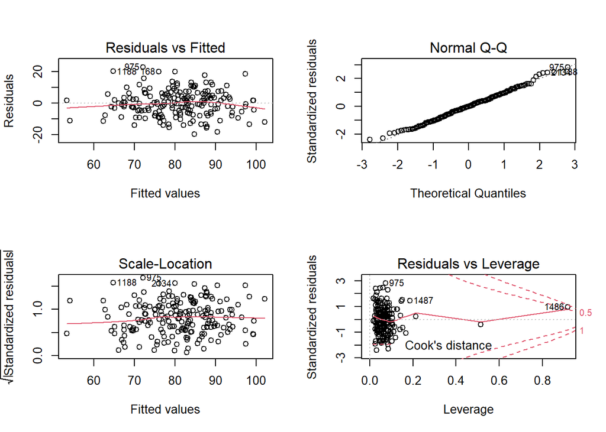

```
## [1] "Shapiro test for normality: The p-value of 0.662651426694407 is > 0.05, so do not reject the null; i.e., the residuals are normal."
## [1] "Breusch-Pagan test for homoschedasticity: The p-value of 0.831798626885522 is > 0.05 and the test statistic of 8.17822169758864 is < 10, so don't reject the null; i.e., the residuals are homoschedastic."
## [1] "Adjusted R-squared value: 0.516965248982435"
## [1] "Mean squared error: 65.7001049832636"
## [1] "--------------------------------------------------"
## lm(formula = model_params, data = train_df, na.action = na.exclude)
```

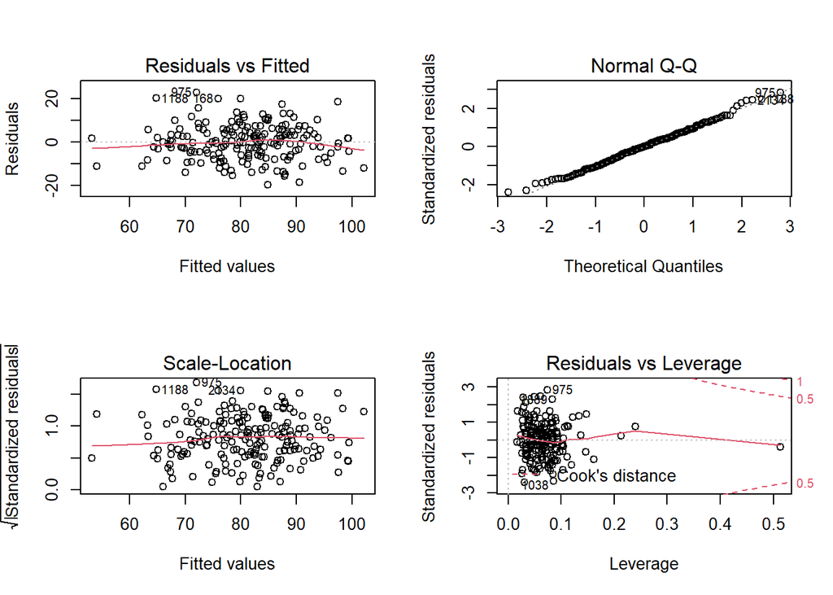